# Impacto Asimétrico de la Crisis del 2008 en la Posición de Inversión Internacional en Europa

Abel Castro Villar

2025-12-06

[Cuadro de mandos](http://10.22.143.222:3838/sample-apps/a2611/aedv/Dashboard_Proyecto.Rmd)

[figure not shown]

# 1 Introducción

En un mundo cada vez más interconectado, los movimientos de capital y la inversión internacional juegan un papel decisivo en la estabilidad económica de los países. La **Posición de Inversión Internacional (IIP)** refleja el valor acumulado de los activos y pasivos financieros que un país mantiene frente al resto del mundo, ofreciendo una visión clara de su situación externa y de su capacidad para financiarse o invertir en el exterior. Este indicador permite analizar si una economía es netamente acreedora o deudora y cómo se adapta a diferentes condiciones económicas.

La **crisis financiera de 2008** representó un momento crítico para las economías europeas, generando impactos significativos sobre la IIP de los países más expuestos. Mientras algunos países mantuvieron posiciones relativamente estables, otros experimentaron **fluctuaciones marcadas**, evidenciando **asimetrías estructurales** en su exposición financiera internacional.

Comprender cómo se desarrollaron estas diferencias y qué factores explican los comportamientos divergentes es fundamental para evaluar la **resiliencia** de cada economía ante **shocks financieros**.

En este contexto, el presente trabajo se centra en el análisis de la **Posición de Inversión Internacional** de **España**, **Italia** y **Alemania** durante la crisis de 2008, utilizando el conjunto de datos “bop_iip6_q” de Eurostat. Aplicando herramientas de ciencia de datos y siguiendo la metodología **CRISP-DM**, se pretende identificar patrones, tendencias y asimetrías en la forma en que estos países respondieron al shock financiero global, aportando una visión cuantitativa y detallada de su evolución financiera internacional durante este periodo crítico.

## 1.1 Estado actual

La **Posición de Inversión Internacional (IIP)** es un indicador fundamental para comprender la exposición financiera de un país frente al resto del mundo. Representa el saldo acumulado de los activos y pasivos financieros de un país, indicando si una economía es netamente **acreedora** o **deudora**, y reflejando su capacidad para financiarse, invertir o asumir riesgos financieros internacionales. Su análisis permite evaluar la **resiliencia económica** y la **estabilidad externa** de los países frente a crisis económicas.

Diversos estudios y reportes de organismos internacionales como el Banco Central Europeo (BCE), Eurostat y el Fondo Monetario Internacional (FMI) han documentado las **diferencias estructurales** en la IIP dentro de la **Zona Euro**. Por ejemplo, se ha observado que Alemania mantiene **posiciones acreedoras** estables, mientras que España e Italia muestran **fluctuaciones significativas**, especialmente durante la crisis financiera de 2008. Estas diferencias reflejan una **asimetría estructural** que afecta la capacidad de respuesta de cada país frente a perturbaciones económicas.

La relevancia del estudio se refuerza considerando que la **crisis de 2008** alteró los flujos financieros internacionales, generando patrones que influyeron directamente en la **estabilidad externa** de los países analizados. La investigación sobre la IIP permite identificar cómo las economías más vulnerables se ajustaron frente al shock financiero y cómo las más sólidas mantuvieron su posición, aportando información clave para **políticas económicas** y decisiones estratégicas a nivel regional.

Aplicar **técnicas de ciencia de datos** al análisis de la Posición de Inversión Internacional ofrece la oportunidad de explorar **patrones ocultos**, visualizar **tendencias** a lo largo del tiempo y cuantificar las **asimetrías** entre los países seleccionados. Utilizando el conjunto de datos “bop_iip6_q” de Eurostat, este estudio se centra en España, Italia y Alemania, permitiendo analizar de **manera comparativa y rigurosa** la evolución de sus posiciones financieras internacionales y su respuesta ante la crisis financiera de 2008.

## 1.2 Motivación

La elección de este tema surge del interés por analizar las **asimetrías** en la **Posición de Inversión Internacional (IIP)** entre los principales países europeos y cómo estas se vieron afectadas por la **crisis financiera de 2008**. Este enfoque resulta especialmente interesante porque permite combinar análisis económico con técnicas de ciencia de datos, explorando patrones y tendencias que no siempre son evidentes a simple vista.

Además, este proyecto puede asentar las bases para un futuro TFG más amplio, al ofrecer un marco metodológico y un conocimiento profundo de los datos financieros internacionales, que se podría ampliar posteriormente para incluir más países, períodos históricos o **técnicas de modelización avanzadas**. Esto proporciona una oportunidad para desarrollar un trabajo que sea relevante académica y profesionalmente.

Desde el punto de vista profesional, el análisis de la **IIP** y de su comportamiento durante la crisis de 2008 resulta particularmente valioso. Comprender cómo se distribuyeron los riesgos y las oportunidades financieras entre países europeos ofrece conocimientos aplicables en áreas como la **consultoría económica**, la **planificación financiera internacional** o la **gestión de riesgos**, campos con creciente demanda de profesionales que combinen economía y análisis de datos.

Finalmente, a nivel personal, el proyecto representa la posibilidad de aplicar **herramientas de ciencia de datos** a un problema económico real y actual, transformando información compleja en conocimiento útil y comprensible, y desarrollando habilidades que serán clave para estudios futuros y para la carrera profesional. Así, el análisis de la **Posición de Inversión Internacional** durante la crisis de 2008 no solo aporta valor académico, sino que también abre nuevas oportunidades de aprendizaje y aplicación profesional.

## 1.3 Objetivos

El objetivo principal de este trabajo es analizar el impacto de la Crisis Financiera Global de 2008 sobre la **Posición de Inversión Internacional (IIP)** de **España**, **Alemania** e **Italia**, evaluando cómo afectó la estabilidad financiera y la capacidad de recuperación de cada economía.

Los objetivos específicos son:

- **Identificar diferencias estructurales** entre los países y cuantificar la magnitud del shock mediante modelos de series temporales y escenarios contrafactuales.
- **Evaluar la calidad del ajuste post-crisis** y determinar la predictibilidad y resiliencia de sus trayectorias hasta 2024, utilizando métricas de error de predicción como el MAPE.
- **Proporcionar herramientas de visualización y análisis**, como gráficos comparativos y un cuadro de mandos interactivo, que faciliten la interpretación de los resultados y apoyen la toma de decisiones basada en evidencia.

# 2 Aportaciones del trabajo

El presente trabajo realiza una contribución significativa al análisis de la **estabilidad financiera europea** al ofrecer un enfoque **cuantitativo** y **comparativo** de las trayectorias de la **IIP** de los paises seleccionados. Las principales aportaciones son las siguientes:

## 2.1 Principales aportaciones

### 2.1.1 Cuantificación Rigurosa del Impacto Asimétrico

Se ha utilizado la **modelización de series temporales (ARIMA)** para cuantificar el efecto neto de la **crisis de 2008** en la **IIP Neta**, lo cual va más allá de la mera descripción histórica. El análisis de **escenarios contrafactuales** probó:

-El **refuerzo estructural** de la posición acreedora de **Alemania**.

-La **interrupción forzada** de la tendencia de deterioro en las economías deudoras (**España** e **Italia**).

### 2.1.2 Establecimiento de la Estabilidad como Métrica Clave

La aportación más relevante es el uso de la calidad de la **capacidad predictiva (MAPE)** como indicador de la **estabilidad estructural** en la fase de recuperación. Los resultados revelaron una distinción crucial entre los deudores:

-**Estabilidad en España**: la serie post-crisis de España es altamente **predecible** (MAPE bajo), lo que confirma una trayectoria de **ajuste eficaz**.

-**Vulnerabilidad en Italia**: la serie italiana demostró ser profundamente **inestable** e **impredecible** (MAPE extremadamente alto), lo que subraya una fragilidad estructural persistente.

### 2.1.3 Aportación Metodológica y Práctica

El proyecto culmina con el desarrollo de un **cuadro de mandos interactivo** (flexdashboard y Shiny). Este aporte asegura que el análisis técnico sea **accesible** y **aplicable a la toma de decisiones** por parte de responsables institucionales, transformando la evidencia cuantitativa en una herramienta dinámica para la **gestión de riesgos** y la **política económica**.

### 2.1.4 Nuevas Líneas de Investigación

Se establece un **marco metodológico sólido** para futuros estudios, sugiriendo la necesidad de incorporar **modelos multivariantes (VAR/VECM)** y el **análisis desagregado de componentes** para entender mejor los **efectos de contagio** y las **fuentes sectoriales** de la estabilidad/vulnerabilidad.

## 2.2 Alineamiento con los objetivos de desarrollo sostenible

El análisis del impacto asimétrico de la crisis financiera de 2008 entre distintos países europeos guarda una relación directa con varios Objetivos de Desarrollo Sostenible (ODS), debido a que la crisis afectó simultáneamente a dimensiones económicas, sociales e institucionales que forman parte de la Agenda 2030. Aunque algunos objetivos presentan una vinculación reducida o no aplicable al alcance del estudio, otros se ven claramente influenciados por los mecanismos económicos analizados, especialmente aquellos relacionados con crecimiento, desigualdad y bienestar económico.

Grado de relación del proyecto con los objetivos de desarrollo sostenible (ODS)

| ODS | No procede | Bajo | Medio | Alto |
| --- | --- | --- | --- | --- |
| 1 Fin de la Pobreza |  |  |  | X |
| 2 Hambre cero | X |  |  |  |
| 3 Salud y Bienestar |  |  | X |  |
| 4 Educación de calidad | X |  |  |  |
| 5 Igualdad de género | X |  |  |  |
| 6 Agua limpia y saneamiento |  | X |  |  |
| 7 Energía Asequible y no contaminante |  | X |  |  |
| 8 Trabajo decente y crecimiento económico |  |  |  | X |
| 9 Industria, Innovación e Infraestructuras |  |  | X |  |
| 10 Reducción de las desigualdades |  |  | X |  |
| 11 Ciudades y comunidades sostenibles |  | X |  |  |
| 12 Producción y consumo sostenibles |  | X |  |  |
| 13 Acción por el clima |  |  | X |  |
| 14 Vida submarina |  | X |  |  |
| 15 Vida de ecosistemas terrestres |  | X |  |  |
| 16 Paz, justicia e instituciones sólidas | X |  |  |  |
| 17 Alianzas para lograr objetivos |  | X |  |  |

En primer lugar, el trabajo tiene una relación alta con el ODS 1 (Fin de la pobreza), ya que las diferencias en el ajuste económico y financiero tras la crisis tuvieron repercusiones significativas sobre los niveles de vulnerabilidad económica de los países más afectados. Las dinámicas de endeudamiento externo, el deterioro de las posiciones financieras internacionales y la lenta recuperación de algunos Estados intensificaron riesgos de pobreza y exclusión, especialmente en el sur de Europa.

Asimismo, el estudio se vincula estrechamente con el ODS 8 (Trabajo decente y crecimiento económico), puesto que la crisis de 2008 provocó fuertes contracciones del PIB, destrucción de empleo y divergencias en los ritmos de recuperación entre países. Analizar estos efectos permite entender cómo la estabilidad macroeconómica y la resiliencia financiera son elementos clave para sostener el crecimiento inclusivo y la creación de empleo de calidad.

Por otra parte, existe una relación media con el ODS 3 (Salud y bienestar), ya que las contracciones económicas prolongadas influyen indirectamente en el bienestar de la población, en el acceso a servicios y en la estabilidad social. También se observa una vinculación media con el ODS 13 (Acción por el clima), en la medida en que las crisis económicas alteran patrones de inversión pública y privada, afectando temporalmente la transición hacia modelos productivos más sostenibles.

En conjunto, este trabajo contribuye a comprender cómo los shocks financieros profundos, como el de 2008, generan efectos duraderos sobre el crecimiento, la desigualdad, la estabilidad institucional y el bienestar socioeconómico, elementos que se encuentran en el núcleo de la Agenda 2030. A través del análisis de la evolución de la posición inversora internacional y del comportamiento de las economías europeas, el estudio ofrece una perspectiva alineada con los ODS más estrechamente relacionados con el desarrollo económico sostenible y la cohesión social.

# 3 Desarrollo

## 3.1 Herramientas empleadas

Para el desarrollo de este trabajo se utilizó **R**, un lenguaje especializado en **análisis estadístico** y **modelización de datos**, junto con **RStudio** como entorno de desarrollo, lo que permitió organizar de manera eficiente todas las fases del proyecto: limpieza, transformación, análisis, modelización y visualización de datos.

Se emplearon diversas **librerías de R**, seleccionadas por su funcionalidad y robustez:

- **Manipulación y preparación de datos**: tidyverse, dplyr, lubridate, zoo y openxlsx para estructurar series temporales y procesar datos económicos de manera reproducible.
- **Análisis y modelización de series temporales**: forecast, fpp3 y tseries para construir modelos ARIMA, evaluar su desempeño y generar escenarios contrafactuales.
- **Visualización y presentación de resultados**: ggplot2, plotly, highcharter, leaflet, patchwork y flexdashboard para crear gráficos estáticos e interactivos, mapas y dashboards, facilitando la interpretación de los resultados.
- **Exportación y reportes**: DT, kableExtra y htmlwidgets para generar tablas dinámicas y documentos exportables en formatos accesibles.

El **cuadro de mandos interactivo** desarrollado con **flexdashboard** y desplegado en el **servidor Shiny del DIS** permite consultar de forma dinámica los datos, series históricas y escenarios contrafactuales, facilitando la toma de decisiones basada en evidencia y el acceso remoto a los resultados por parte de usuarios institucionales.

En conjunto, la combinación de **R**, sus **librerías** y el entorno **Shiny** permitió integrar **análisis estadístico riguroso**, **modelización predictiva** y **visualización interactiva**, asegurando resultados reproducibles, interpretables y de aplicación práctica.

## 3.2 Metodología

Utilizaremos la metodología de desarrollo CRISP-DM (Cross Industry Standard Process for Data Mining) que es un marco ampliamente utilizado para proyectos de Ciencias de Datos. En la siguiente figura se presenta un diagrama con las diferentes fases de esta metodología que a continuación describimos con más detalle:

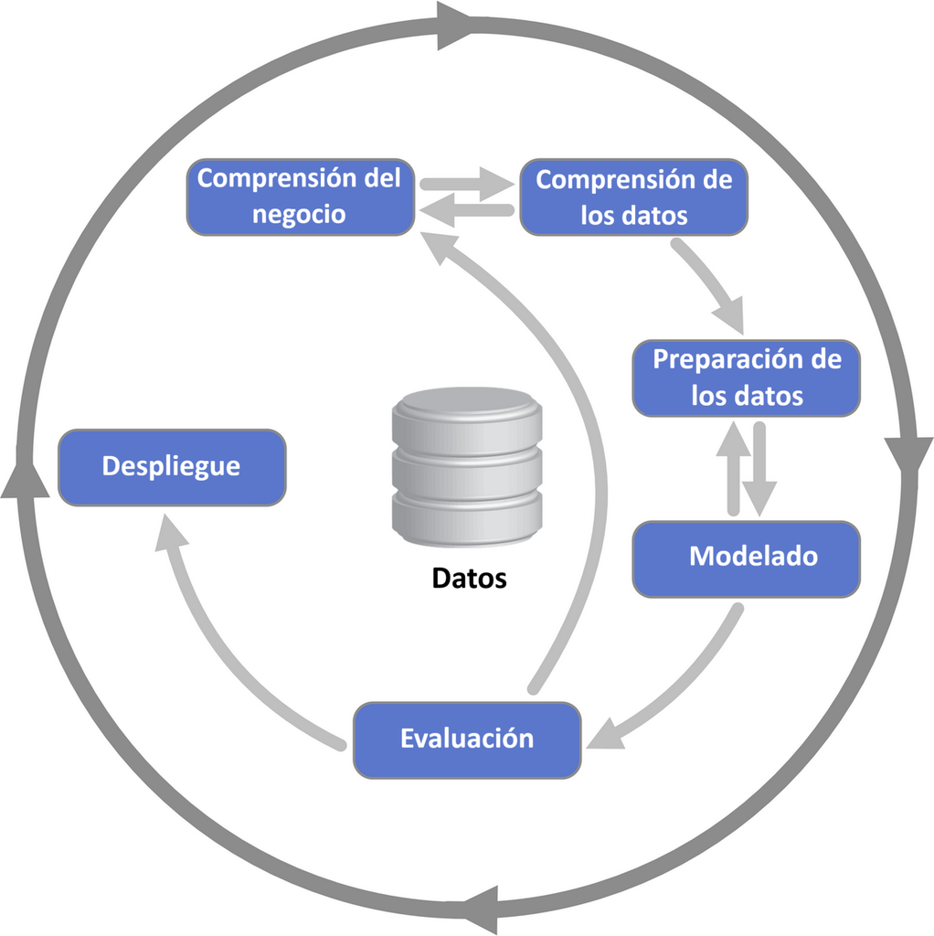

*Diagrama metodología de desarrollo CRISP-DM*

- **Comprensión del negocio**. Se plantean los objetivos del proyecto y la búsqueda de información y datos.
- **Comprensión de los datos**. Se analiza la estructura y organización de los datos obtenidos. Se identifican posible problemas como datos faltantes, outliers o inconsistencias.
- **Preparación de los datos**. Se realiza limpieza, transformación, combinación y selección/creación de variables relevantes para el análisis
- **Modelado**. Selección y aplicación de los modelos adecuados para analizar los datos
- **Evaluación**. Evaluar si el modelo responde a las preguntas de investigación, comparación con otros métodos
- **Despliegue**. Comunicación del trabajo en una memoria y diseño y elaboración de un cuadro de mandos para presentar los resultados de forma eficaz y atractiva.

Es importante observar que esta metodología es iterativa, es decir que los resultados obtenidos en algunas de las fases puede afectar al desarrollo de fases anteriores.

A continuación se describirá en detalle como se han abordado cada una de las fases del desarrollo del proyecto siguiendo esta metodología.

## 3.3 Comprensión del negocio

El presente trabajo se enmarca dentro de las consecuencias **macroeconómicas** generadas por la **Crisis Financiera Global de 2008** y la posterior **Crisis de Deuda Soberana** en la **Zona Euro**. Estos eventos expusieron profundas **fragilidades estructurales** y una marcada **asimetría** entre las economías de los países del **núcleo** (como **Alemania**) y los países de la **periferia** (como **España** e **Italia**).

### 3.3.1 Definición del Problema

El problema central que aborda esta investigación es la **divergencia económica** y **financiera** que se acentuó en la **Unión Monetaria** tras la crisis. Específicamente, se busca analizar el impacto sobre la **Posición de Inversión Internacional Neta (IIP Neta)**.

La **IIP Neta** es la diferencia entre los **activos financieros** que un país posee en el exterior y los **pasivos financieros** que tiene frente a no residentes. Es un indicador clave de la **solvencia externa** y la **vulnerabilidad** de una economía. Un saldo negativo creciente (**posición deudora**) aumenta la dependencia del país de la **financiación externa** y su exposición a **shocks de confianza**, mientras que un saldo positivo (**posición acreedora**) refuerza su posición global.

### 3.3.2 Objetivo del Análisis

El objetivo principal de este proyecto es cuantificar el **impacto asimétrico** de la **crisis de 2008** en la trayectoria de la **IIP Neta**, comparando tres economías representativas:

- **Alemania**: representante del **núcleo acreedor** y de la **estabilidad**.
- **España** e **Italia**: representantes de la **periferia deudora**, pero con diferentes **estructuras económicas** subyacentes.

### 3.3.3 Preguntas Clave a Responder

Para alcanzar este objetivo, el análisis se centra en las siguientes preguntas de investigación:

- ¿Cuál fue el **efecto neto** del **shock de 2008**? Es decir, ¿cómo se desvió la **IIP Neta real** de cada país respecto a la trayectoria que habría seguido en un **escenario contrafactual** (sin crisis)?
- ¿Cuál es la naturaleza del **ajuste post-crisis**? ¿La recuperación se basa en **patrones estables** y **predecibles** o persiste la **volatilidad estructural**?
- ¿Cómo se traduce esta **asimetría** en términos de **estabilidad financiera**? ¿La calidad de la recuperación de **España** es comparable a la de **Italia**, o la divergencia en la **estabilidad** (predictibilidad) es la verdadera métrica de la asimetría?

### 3.3.4 Metodología y Valor Añadido

Para responder a estas preguntas, el proyecto utiliza la **modelización de series temporales (modelos ARIMA)**. La elección de esta **metodología** es fundamental, ya que permite:

- **Construir Escenarios Contrafactuales**: cuantificar el impacto directo de un evento **exógeno** (la crisis) aislando la influencia de la **tendencia histórica** previa.
- **Evaluar la Estabilidad Post-Crisis**: medir la **capacidad predictiva** de los modelos (a través del **MAPE** y el **AIC**) en el período de recuperación (2016-2024), lo cual sirve como indicador de la **solidez** y la **calidad estructural** de la nueva trayectoria de la **IIP Neta** de cada país.

En definitiva, este trabajo busca ir más allá de la mera descripción de **saldos** para ofrecer una **medición rigurosa y predictiva** de la **divergencia económica** en la **Zona Euro**.

## 3.4 Comprensión de los datos

### 3.4.1 Explicación de las variables categóricas

```
##
##
## ## COLUMNA: freq
## # Es la frecuencia con la que se toman las observaciones. Sus valores posibles son:
## -Q: datos trimestrales
## -A: datos anuales
##      freq N.Observ
## [1,] Q    46435651
## [2,] A    11399190
##
##
## ## COLUMNA: currency
## # Es la unidad monetaria en la que se miden las observaciones. Sus valores posibles son:
## -MIO_EUR: millones de euros
## -MIO_NAC: millones de la moneda nacional
##      currency N.Observ
## [1,] MIO_EUR  28967302
## [2,] MIO_NAC  28867539
##
##
## ## COLUMNA: bop_item
## # Tipo de inversión o instrumento financiero. Sus valores posibles son:
## FA__O__F: Cuenta financiera correspondiente a otras inversiones. 'FA' indica que pertenece a la cuenta financiera dentro de la balanza de pagos. 'O' significa otras inversiones, es decir, activos financieros que no son inversión directa ni inversión de cartera. 'F' es la categoría general dentro …
## FA__O__F81: Subcategoría de otras inversiones centrada en el comercio de préstamos a corto plazo. FA es cuenta financiera, O son otras inversiones y F81 indica préstamos con vencimiento rápido, generalmente menor a un año. Este valor permite analizar la liquidez y la exposición a riesgos de crédi…
## FA__P__F3__L: Inversión de cartera en bonos y valores a largo plazo. FA es cuenta financiera, P indica inversión de cartera, F3 se refiere a deuda y L significa largo plazo. Representa títulos de deuda emitidos por gobiernos o empresas con vencimiento superior a un año, útiles para medir exposici…
## FA__F__F7: Derivados financieros. FA es cuenta financiera, F indica instrumentos derivados, F7 es el código específico de derivados. Representa contratos cuyo valor depende de un activo subyacente como acciones, bonos o divisas, usados para cobertura de riesgos o inversión especulativa
## FA__O__F4: Préstamos dentro de otras inversiones. FA es cuenta financiera, O son otras inversiones, F4 identifica préstamos no clasificados en inversión directa o de cartera. Incluye créditos otorgados a residentes extranjeros o empresas internacionales, permitiendo analizar relaciones financiera…
## FA__P__F3__S: Bonos y valores a corto plazo dentro de inversión de cartera. FA es cuenta financiera, P es inversión de cartera, F3 indica deuda y S señala corto plazo. Incluye títulos de deuda con vencimiento inferior a un año, útiles para medir liquidez y riesgo de corto plazo
## FA__O__F6: Seguros y fondos de pensiones dentro de otras inversiones. FA es cuenta financiera, O son otras inversiones, F6 indica seguros y fondos de pensiones. Refleja inversiones en el sector asegurador y fondos de pensiones, permitiendo analizar exposición y retornos de este sector financiero …
## FA__O__F2: Depósitos dentro de otras inversiones. FA es cuenta financiera, O son otras inversiones, F2 indica depósitos. Representa depósitos bancarios u otros instrumentos de depósito mantenidos por residentes extranjeros, proporcionando información sobre liquidez internacional y disponibilidad …
## FA__D__FL: Préstamos dentro de inversión directa. FA es cuenta financiera, D indica inversión directa y FL significa préstamos. Representa préstamos otorgados por empresas a filiales o entidades vinculadas, mostrando relaciones financieras internas dentro de grupos empresariales y flujo de capita…
## FA__O__F81__S: Subcategoría de comercio de préstamos a corto plazo en otras inversiones. FA es cuenta financiera, O son otras inversiones, F81 indica préstamos a corto plazo y S señala subcategoría específica. Permite analizar de forma detallada la exposición a préstamos de vencimiento rápido en …
## FA__O__F81__L: Subcategoría de préstamos a largo plazo dentro de comercio de préstamos en otras inversiones. FA es cuenta financiera, O son otras inversiones, F81 indica préstamos y L señala largo plazo. Analiza préstamos con vencimiento extendido y su impacto en la liquidez
## FA__O__F4__L: Préstamos a largo plazo dentro de otras inversiones. FA es cuenta financiera, O son otras inversiones, F4 indica préstamos y L largo plazo. Permite evaluar la exposición a préstamos con vencimiento prolongado
## FA__D__F5: Participaciones en capital dentro de inversión directa. FA es cuenta financiera, D inversión directa y F5 indica participaciones en capital. Representa la propiedad de acciones que otorgan influencia significativa en empresas relacionadas, mostrando control y participación en la gestió…
## FA__O__F89__S: Subcategoría de otras inversiones a corto plazo. FA es cuenta financiera, O otras inversiones, F89 residual y S corto plazo. Incluye activos residuales con vencimiento rápido que no encajan en categorías previas
## FA__O__F4__S: Préstamos a corto plazo dentro de otras inversiones. FA es cuenta financiera, O otras inversiones, F4 préstamos y S corto plazo. Son préstamos con vencimiento menor a un año, importantes para análisis de liquidez
## FA__P__F51: Acciones y participaciones dentro de inversión de cartera. FA es cuenta financiera, P inversión de cartera, F51 acciones y participaciones. Se centra en inversiones en renta variable, permitiendo analizar exposición a capital y riesgo de mercado
## FA__O__F89: Subcategoría residual de otras inversiones. FA cuenta financiera, O otras inversiones, F89 residual. Captura activos financieros que no encajan en categorías anteriores, permitiendo análisis de instrumentos menos comunes
## FA__O__F89__L: Subcategoría residual de otras inversiones a largo plazo. FA cuenta financiera, O otras inversiones, F89 residual y L largo plazo. Permite identificar activos de vencimiento extendido que no forman parte de categorías principales
```

[output cut: 413 more lines]

```
## [21,] 2011-01-01  2091720
## [22,] 2012-01-01  2268694
## [23,] 2013-01-01  3382161
## [24,] 2014-01-01  3447440
## [25,] 2015-01-01  3651070
## [26,] 2016-01-01  3782723
## [27,] 2017-01-01  3882987
## [28,] 2018-01-01  3955969
## [29,] 2019-01-01  4093293
## [30,] 2020-01-01  3736051
## [31,] 2021-01-01  3424648
## [32,] 2022-01-01  3180438
## [33,] 2023-01-01  2477778
## [34,] 2024-01-01  2395934
## [35,] 2025-01-01   482359
```

### 3.4.2 Análisis de la longitud de las series temporales

Realicé un **análisis de las series temporales**, inspeccionando **estadísticas descriptivas** como **máximos**, **mínimos** y **percentiles** de la longitud de cada serie, con el fin de comprender la **estructura de los datos** antes de aplicar diferentes **modelos**. Los resultados muestran que el **tamaño máximo** es de **137 puntos**, mientras que menos del **10%** de las series superan los **100 puntos**, lo que indica que la mayoría de las series son relativamente **cortas** y **homogéneas**. Esta **homogeneidad** se debe a que los **datos** provienen de **observaciones** con **frecuencia** y **duración similares**, lo que asegura que las series estén listas para ser **procesadas** y **modeladas**.

```
## # A tibble: 1 × 7
##     min   p10   p25   p50   p75   p90   max
##   <int> <dbl> <dbl> <dbl> <dbl> <dbl> <int>
## 1     1     5    12    19    49    69   137
```

### 3.4.3 Distribución del nº de observaciones por regiones

- **Percentiles de la distribución del nº de observaciones por regiones**

```
## # A tibble: 1 × 7
##     min    p10     p25     p50     p75      p90     max
##   <int>  <dbl>   <dbl>   <dbl>   <dbl>    <dbl>   <int>
## 1   426 24590. 296214. 1424664 1860409 2707634. 5149512
```

- **Nº de observaciones en España**

```
## # A tibble: 1 × 3
##   geo   full_name N.Observ
##   <chr> <chr>        <int>
## 1 ES    Spain      1440940
```

### 3.4.4 Combinaciones existentes de las variables categóricas

```
## # A tibble: 1,855,714 × 11
## # Groups:   freq, currency, bop_item, sector10, sectpart, stk_flow, partner
## #   [230,170]
##    freq  currency bop_item     sector10 sectpart stk_flow partner geo   N.observ
##    <chr> <chr>    <chr>        <chr>    <chr>    <chr>    <chr>   <chr>    <int>
##  1 Q     MIO_EUR  FA__P__F5    S121     S1       A_LE     WRL_RE… FR         137
##  2 Q     MIO_EUR  FA__P__F51   S121     S1       A_LE     WRL_RE… FR         137
##  3 Q     MIO_EUR  FA__P__F51   S121     S1       L_LE     WRL_RE… FR         137
##  4 Q     MIO_EUR  FA__P__F51   S121     S1       N_LE     WRL_RE… FR         137
##  5 Q     MIO_EUR  FA__P__F52   S121     S1       A_LE     WRL_RE… FR         137
##  6 Q     MIO_EUR  FA__P__F52   S121     S1       A_LE     WRL_RE… RS         137
##  7 Q     MIO_NAC  FA__P__F5    S121     S1       A_LE     WRL_RE… FR         137
##  8 Q     MIO_NAC  FA__P__F51   S121     S1       A_LE     WRL_RE… FR         137
##  9 Q     MIO_NAC  FA__P__F51   S121     S1       L_LE     WRL_RE… FR         137
## 10 Q     MIO_NAC  FA__P__F51   S121     S1       N_LE     WRL_RE… FR         137
```

[output cut: 42 more lines]

## 3.5 Preparación de los datos

La **preparación de los datos** constituye un paso crucial para garantizar la **calidad**, **consistencia** y **relevancia** de las series temporales utilizadas en este estudio. Para ello, se seleccionó exclusivamente la información necesaria para el análisis, priorizando los elementos que resultan más significativos durante el **periodo de crisis** y en los países donde se aprecia mayor **asimetría económica**.

Se trabajó con **datos trimestrales** expresados en millones de euros, centrándose en los **instrumentos financieros** más relevantes: cuenta financiera total, inversión directa, inversión en cartera, otros instrumentos de inversión y reservas oficiales del banco central. Asimismo, se delimitaron los **sectores económicos de interés**, total de la economía, bancos centrales, otras instituciones financieras, administraciones públicas y sociedades no financieras, y los **países estudiados**: **España**, **Alemania** e **Italia**. La selección de **contrapartes** también se acotó a las más significativas para el análisis internacional, incluyendo el Resto del mundo, Zona Euro, Fuera de la Zona Euro, Unión Europea y Estados Unidos.

El **periodo temporal** considerado abarca desde el **año 2000 hasta 2024**, lo que permite generar series temporales completas y consistentes, esenciales para evaluar la **capacidad predictiva** de los modelos aplicados. Se eliminaron valores faltantes y variables irrelevantes, asegurando un conjunto de datos limpio y homogéneo.

Además, se realizaron **transformaciones adicionales** para facilitar la **interpretación** y el **análisis**: se renombraron las variables con nombres claros y descriptivos, se recodificaron los valores de las categorías para que fueran fácilmente comprensibles, por ejemplo, los flujos financieros se codificaron como ‘Activos, ’Pasivos y ’Neto’, y los instrumentos financieros recibieron nombres completos y explícitos, y se reorganizó la estructura de la tabla final, conservando únicamente las columnas esenciales.

Estas tareas de preparación permiten disponer de un **conjunto de datos depurado**, **coherente** y **estructurado**, listo para la construcción de las series temporales y la aplicación de los modelos predictivos presentados en los capítulos posteriores. La limpieza y estandarización de la información garantizan que los resultados obtenidos sean robustos y comparables, aportando **rigor** al **análisis económico** que sustenta este trabajo.

| pais | periodo | contraparte | instrumento financiero | sector | flujo | moneda | valor |
| --- | --- | --- | --- | --- | --- | --- | --- |
| Alemania | 2000-01-01 | Resto del mundo | Cuenta financiera total | Total Economía | Activos | Millones EUR | 2925611 |
| Alemania | 2000-01-01 | Resto del mundo | Cuenta financiera total | Total Economía | Pasivos | Millones EUR | 2891620 |
| Alemania | 2000-01-01 | Resto del mundo | Cuenta financiera total | Total Economía | Neto | Millones EUR | 33991 |
| Alemania | 2000-01-01 | Resto del mundo | Inversión Directa | Total Economía | Activos | Millones EUR | 590738 |
| Alemania | 2000-01-01 | Resto del mundo | Inversión Directa | Total Economía | Pasivos | Millones EUR | 564772 |
| Alemania | 2000-01-01 | Resto del mundo | Inversión Directa | Total Economía | Neto | Millones EUR | 25966 |
| Alemania | 2000-01-01 | Resto del mundo | Otros instrumentos de inversión | Total Economía | Activos | Millones EUR | 432999 |
| Alemania | 2000-01-01 | Resto del mundo | Otros instrumentos de inversión | Total Economía | Pasivos | Millones EUR | 173077 |
| Alemania | 2000-01-01 | Resto del mundo | Otros instrumentos de inversión | Total Economía | Neto | Millones EUR | 259922 |
| Alemania | 2000-01-01 | Resto del mundo | Otros instrumentos de inversión | Bancos Centrales | Activos | Millones EUR | 0 |

[output cut: 2990 more lines]

- **Posición de Inversión Internacional Neta**

Para obtener una **visión general** de los países seleccionados, se analiza la **Posición de Inversión Internacional Neta** de España, Alemania e Italia a lo largo del periodo 2000-2024. Esta representación permite comparar de manera directa la evolución de cada economía y evaluar diferencias en magnitud, dirección y estabilidad de los flujos frente a perturbaciones externas.

La franja roja sombreada indica los años más intensos de la **Crisis Financiera Global (2008-2011)**, facilitando la interpretación de cómo cada país reaccionó ante los distintos shocks económicos. Esta visualización constituye un primer diagnóstico visual de las dinámicas internacionales de inversión y sirve como base para los análisis cuantitativos y los modelos predictivos que se desarrollan en capítulos posteriores.

[interactive chart not shown]

- **Distribución de Activos y Pasivos por Año y País**

A continuación, se descompone la **inversión internacional** de los tres países mostrando la distribución de **activos** y **pasivos** de la economía total a lo largo del tiempo. La utilización de **barras apiladas** y facetas por país permite comparar cómo varió la composición de los flujos en cada país y cómo respondieron a los **periodos de crisis**.

Esta visualización evidencia no solo la magnitud relativa de los activos y pasivos en cada economía, sino también la **capacidad de cada país para ajustar sus posiciones** frente a **shocks externos**, ofreciendo un análisis más detallado que complementa la **posición neta comparativa**.

[interactive chart not shown]

- **Composición de Activos de España**

Para profundizar en la **composición de los activos**, se analiza la distribución de los activos españoles por tipo de **instrumento financiero**. Esta visualización evidencia cuáles instrumentos fueron más relevantes antes, durante y después de la **Crisis Financiera Global**. Las líneas punteadas señalan el inicio y el fin del periodo más intenso de la crisis (2008-2011), facilitando la identificación de cambios significativos en la **estructura de los activos**. Este análisis aporta información sobre la resiliencia de los distintos instrumentos frente a shocks externos y complementa la perspectiva proporcionada por los flujos netos y brutos.

[interactive chart not shown]

- **Distribución de Activos de España por Contraparte**

Finalmente, se presenta la **distribución acumulada** de los **activos españoles** según la **contraparte**, lo que permite identificar qué contrapartes concentraron la mayor parte de la inversión y evaluar la **diversificación** frente a riesgos de concentración. Esta gráfica proporciona información crucial sobre la exposición internacional del país y facilita la interpretación de la **dinámica global de los flujos de capital**.

[figure not shown]

En conjunto, estas visualizaciones ofrecen una comprensión integral de la inversión internacional de España, mostrando la relación entre posición neta, composición de flujos, estructura de activos y concentración por contrapartes. La combinación de análisis comparativo entre países y desagregado dentro de España permite identificar patrones de resiliencia, vulnerabilidad y ajuste frente a crisis económicas, sentando las bases para los análisis predictivos que se presentan en los capítulos siguientes.

## 3.6 Modelado

En esta sección se procede al análisis de la **Posición de Inversión Internacional (IIP)** neta de los países seleccionados, con el objetivo de evaluar cómo la crisis económica ha afectado sus flujos financieros. Se emplean series temporales trimestrales de la cuenta financiera total y se ajustan modelos ARIMA para identificar patrones, tendencias y posibles asimetrías en la reacción de cada país frente al shock económico.

El modelado permite comparar la evolución de la inversión neta antes, durante y después de la crisi, así como generar pronósticos que faciliten evaluar la consistencia de los patrones observados

- **ESPAÑA**

Ahora he modificado la tabla que habia limpiado anteriormente para que las fechas trimestrales esten cada una en su trimestre correspondiente, y no todas con el mismo día.

10 primeras fechas trimestrales aproximadas

| fecha_trimestral | valor |
| --- | --- |
| 2000-02-29 | -231323 |
| 2000-05-31 | -222379 |
| 2000-08-31 | -235584 |
| 2000-11-30 | -226136 |
| 2001-02-28 | -248581 |
| 2001-05-31 | -251102 |
| 2001-08-31 | -252929 |
| 2001-11-30 | -270163 |
| 2002-02-28 | -283710 |
| 2002-05-31 | -289397 |

Como podemos ver en este gráfico, la serie histórica de la **IIP neta de España** muestra una caída sostenida desde comienzos de siglo, reflejando la acumulación de **pasivos** frente al resto del mundo. Durante el periodo de crisis 2008-2011, se observa un frenazo en la caída, que posteriormente veremos como no implica una mejora económica real, sino una interrupción de los flujos de **inversión externa**. Esto sugiere que el efecto de la crisis fue un **ajuste forzoso** de la posición financiera neta, principalmente por la reducción de la exposición de los pasivos externos.

[interactive chart not shown]

- **ALEMANIA**

Como se puede observar, en los primeros años de la serie no se encuentran disponibles todos los datos trimestrales, por lo que algunas fechas están ausentes. Para poder realizar un análisis continuo de la IIP neta, activos y pasivos, será necesario rellenar la serie posteriormente, asegurando que cada trimestre cuente con una observación consistente y permitiendo estudiar correctamente la evolución y los patrones de crecimiento de la economía alemana.

10 primeras fechas trimestrales aproximadas

| fecha_trimestral | valor |
| --- | --- |
| 2000-02-29 | 33991 |
| 2001-05-31 | 142219 |
| 2002-08-31 | -72 |
| 2003-11-30 | 16698 |
| 2004-02-29 | 29652 |
| 2004-05-31 | 89540 |
| 2004-08-31 | 92502 |
| 2004-11-30 | 101988 |
| 2005-02-28 | 162266 |
| 2005-05-31 | 211925 |

[interactive chart not shown]

- **ITALIA**

En el caso de Italia, como podemos ver, la serie cuenta con datos trimestrales completos desde el inicio, lo que permite un análisis continuo y detallado de la evolución de la economía sin necesidad de interpolar o rellenar la información. Esto facilita estudiar con precisión los patrones de ajuste durante la crisis y la recuperación posterior, así como la contribución de cada componente al comportamiento agregado de la posición exterior neta.

10 primeras fechas trimestrales aproximadas

| fecha_trimestral | valor |
| --- | --- |
| 2000-02-29 | -55463 |
| 2000-05-31 | -56475 |
| 2000-08-31 | -64364 |
| 2000-11-30 | -79138 |
| 2001-02-28 | -91521 |
| 2001-05-31 | -80616 |
| 2001-08-31 | -83499 |
| 2001-11-30 | -64082 |
| 2002-02-28 | -60524 |
| 2002-05-31 | -113038 |

Como se aprecia en este gráfico, la serie histórica de la **IIP neta de Italia** muestra una caída sostenida hasta 2007, reflejando el ajuste de los flujos de inversión externa y el desequilibrio entre activos y pasivos, que veremos en los siguiente apartados. Entre 2007 y 2014, la serie se mantiene relativamente estable, lo que indica un período de **contención de la caída** durante la crisis y los años posteriores. A partir de 2014, la IIP neta inicia un crecimiento continuado, mostrando una recuperación sostenida que se mantiene hasta 2019, reflejando la **mejora gradual** de la posición exterior neta del país.

[interactive chart not shown]

## 3.7 Evaluación

### 3.7.1 Modelos predictivos

Comparo varios **modelos ARIMA** para identificar el que mejor captura los patrones de los datos de cada país. Para la selección final, utilizo dos criterios clave:

- **AIC** (Criterio de Información de Akaike): nos indica qué tan bueno es un modelo explicando los datos sin ser **demasiado complicado**. Un modelo que se ajusta perfectamente a los datos históricos pero es muy complejo puede ser engañoso, porque “memoriza” los datos en lugar de aprender los patrones reales.
- **Precisión predictiva** (MAPE): mide, en porcentaje, qué tan lejos están las predicciones del modelo respecto a los datos reales. Es importante porque no basta con que un modelo se ajuste bien a los datos pasados, queremos que prediga correctamente el futuro.
- **España**

En esta tabla muestro los modelos ARIMA probados, mostrando sus parámetros, ajuste a los datos (AIC) y precisión de predicción (MAPE y RMSE) para identificar el mejor modelo.

Comparación Completa de Modelos ARIMA: Parámetros, AIC y Precisión

| Modelo | Parametros | AIC | MAPE | RMSE |
| --- | --- | --- | --- | --- |
| Auto.ARIMA Básico | 0,2,1 | 1521.03 | 7.13 | 71858 |
| Auto.ARIMA Completo | 0,2,3 | 1519.59 | 9.25 | 95440 |
| ARIMA d=1 | 0,1,2 | 1541.42 | 30.92 | 306857 |
| RW con Drift | 0,1,0 | 1550.21 | 31.53 | 312152 |

En esta tabla muestro los modelos ARIMA que obtuvieron el mejor AIC y la mejor precisión predictiva (MAPE), destacando en verde el modelo finalmente seleccionado priorizando la capacidad de predicción.

Selección del Mejor Modelo ARIMA según AIC y MAPE

| Criterio | Modelo | AIC | MAPE | RMSE |
| --- | --- | --- | --- | --- |
| Mejor por AIC | Auto.ARIMA Completo | 1519.59 | 9.25 | 95440 |
| Mejor por MAPE | Auto.ARIMA Básico | 1521.03 | 7.13 | 71858 |
| Criterio final | Auto.ARIMA Básico | 1521.03 | 7.13 | 71858 |

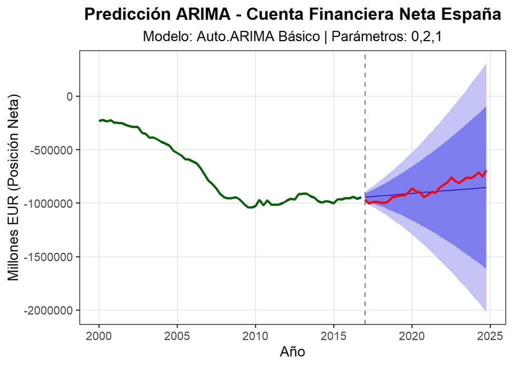

La gráfica resultante muestra, en verde, la evolución histórica de la serie hasta el final del periodo muestral y, en rojo, la trayectoria observada tras la fecha de corte. Sobre esta última se superpone la **predicción** generada por el **modelo**, representada por la línea azul junto con sus intervalos de confianza al 80 % y 95 % (zonas sombreadas). Esta visualización permite apreciar de manera clara la coherencia del modelo con la dinámica reciente de la serie, así como la incertidumbre asociada a las predicciones a medio plazo.

En conjunto, este **modelo** constituye la base para generar el **contrafactual** que se empleará posteriormente en el análisis del impacto de la crisis, al permitir estimar cómo habría evolucionado la **Cuenta Financiera Neta de España** en ausencia de perturbaciones excepcionales.

- **ALEMANIA**

A continuacion muestro los modelos seleccionados para Alemania, junto con los respectivos parámetros para identificar el mejor modelo.

Comparación Completa Modelos ARIMA – Alemania

| Modelo | Parametros | AIC | MAPE | RMSE |
| --- | --- | --- | --- | --- |
| RW con Drift | 0,1,0 | 1657.88 | 19.57 | 623259 |
| Auto.ARIMA Básico | 0,1,1 | 1654.02 | 19.66 | 626100 |
| ARIMA d=1 | 0,1,1 | 1654.02 | 19.66 | 626100 |
| Auto.ARIMA Completo | 0,1,1 | 1654.02 | 19.66 | 626100 |

En esta tabla, de nuevo, muestro los modelos ARIMA que obtuvieron el mejor AIC y la mejor precisión predictiva (MAPE), destacando en verde el modelo finalmente seleccionado priorizando la capacidad de predicción.

Selección del Mejor Modelo ARIMA – Alemania

| Criterio | Modelo | AIC | MAPE | RMSE |
| --- | --- | --- | --- | --- |
| Mejor por AIC | Auto.ARIMA Básico | 1654.02 | 19.66 | 626100 |
| Mejor por MAPE | RW con Drift | 1657.88 | 19.57 | 623259 |
| Criterio final | RW con Drift | 1657.88 | 19.57 | 623259 |

En este caso, tuve que rellenar la serie real prediciendo datos, debido a que como pudimos ver anteriormente, a la serie Alemana le faltaban trimestres para estar completa.

Ahora en el siguiente gráfico veremos reflejada la correspondiente predicción realizada.

[figure not shown]

Este modelo constituye la base para generar el **contrafactual** de **Alemania** en el análisis del impacto de la crisis, proporcionando una estimación consistente de cómo habría evolucionado la **posición financiera neta** del país en ausencia de perturbaciones significativas.

- **ITALIA**

Y por último, muestro los modelos seleccionados para Italia, junto con sus respectivos parámetros para identificar el mejor modelo.

Comparación Completa de Modelos ARIMA: Parámetros, AIC y Precisión – Italia

| Modelo | Parametros | AIC | MAPE | RMSE |
| --- | --- | --- | --- | --- |
| Auto.ARIMA Básico | 1,2,2,0,0,1,4 | 1547.34 | 175.56 | 99877 |
| Auto.ARIMA Completo | 2,2,3 | 1546.73 | 218.04 | 130553 |
| ARIMA d=1 | 2,1,2 | 1564.26 | 468.62 | 254743 |
| RW con Drift | 0,1,0 | 1571.08 | 565.94 | 301528 |

Esta tabla muestra los distintos modelos ARIMA probados, con sus parámetros, ajuste (AIC) y métricas de predicción (MAPE y RMSE), permitiendo identificar cuál ofrece la mayor fiabilidad para las predicciones y destacando el modelo finalmente elegido.

Selección del Mejor Modelo ARIMA según AIC y MAPE – Italia

| Criterio | Modelo | AIC | MAPE | RMSE |
| --- | --- | --- | --- | --- |
| Mejor por AIC | Auto.ARIMA Completo | 1546.73 | 218.04 | 130553 |
| Mejor por MAPE | Auto.ARIMA Básico | 1547.34 | 175.56 | 99877 |
| Criterio final | Auto.ARIMA Básico | 1547.34 | 175.56 | 99877 |

Para el caso de **Italia**, se estimaron múltiples especificaciones **ARIMA**, con el objetivo de identificar el modelo con mejor equilibrio entre capacidad explicativa y precisión predictiva. Tras comparar las alternativas por medio del Akaike Information Criterion (AIC) y del MAPE obtenido en validación, el modelo seleccionado fue un **ARIMA(1,2,2) con estacionalidad (0,0,1)[4]**. Esta estructura refleja la **complejidad** de la dinámica italiana, caracterizada por cambios de tendencia, variabilidad marcada y cierto patrón estacional de baja frecuencia.

El hecho de que el modelo requiera doble diferenciación pone de manifiesto que la serie presenta fuertes comportamientos **no estacionarios**, mientras que los términos **AR** y **MA** permiten capturar dependencias temporales de mayor y menor plazo. La **componente estacional** adicional corrige fluctuaciones recurrentes que aparecen a lo largo del periodo analizado, mejorando la **estabilidad predictiva** del modelo.

Y de nuevo, en la siguiente gráfica, mostramos las predicción que acabamos de explicar.

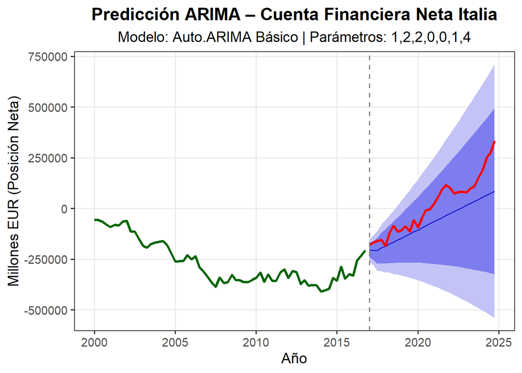

En la gráfica se representa en verde la evolución histórica de la serie hasta la fecha de corte, y en rojo los valores observados posteriormente. La **predicción** generada por el modelo aparece en azul, acompañada de amplios intervalos de confianza al 80 % y 95 % (zonas sombreadas). Estos intervalos relativamente extensos reflejan la elevada **incertidumbre** asociada a la serie italiana, cuya evolución reciente muestra una trayectoria ascendente más pronunciada que la proyectada por el **contrafactual**. Aun así, el modelo reproduce de manera consistente la tendencia general, permitiendo construir una referencia válida sobre cómo habría evolucionado la **posición financiera neta** del país en ausencia de shocks relevantes.

Este modelo sirve como base para estimar el **contrafactual** de **Italia** dentro del análisis del **impacto asimétrico de la crisis**, proporcionando una aproximación robusta a la trayectoria esperada en un escenario sin perturbaciones extraordinarias.

Una vez seleccionado el modelo más adecuado para cada país, el siguiente paso consiste en evaluar su **validez estadística** y comprobar hasta qué punto representa de manera fiable la dinámica de la serie temporal. Para ello, se realiza un análisis detallado de los **residuos** del modelo, ya que un buen ajuste debe dejar como resultado unos residuos que se comporten como **ruido blanco**: sin estructura, sin autocorrelación y con distribución aproximadamente normal. Este análisis es fundamental para confirmar que el modelo no deja patrones sin capturar y que las predicciones obtenidas pueden considerarse robustas.

### 3.7.2 Diagnóstico de los modelos

A continuación, se presentan los principales elementos de diagnóstico del modelo, junto con los criterios que se siguen para evaluar su validez:

- **Residuos en el tiempo**: se inspecciona la evolución de los residuos para detectar posibles patrones, tendencias o anomalías. La ausencia de estructuras sistemáticas indica que el modelo ha capturado correctamente la dinámica de la serie, dejando únicamente **ruido aleatorio**, mientras que la presencia de tendencias o ciclos sugeriría un ajuste insuficiente..
- **Distribución de residuos**: se analiza mediante **histograma con densidad superpuesta** y un **test formal de normalidad**, como el Shapiro–Wilk. El criterio visual indica que los residuos deben estar centrados alrededor de cero y presentar una forma aproximadamente simétrica, sin colas excesivas. Formalmente, la hipótesis nula del test establece que los residuos siguen una distribución normal; se considera que la normalidad es aceptable si el **p-valor > 0.05**, mientras que un **p-valor ≤ 0.05** indica desviaciones significativas respecto a la normalidad.
- **ACF de residuos**: el gráfico de autocorrelación permite identificar posibles correlaciones entre los residuos y los valores pasados de la serie. La mayoría de los coeficientes de autocorrelación deberían permanecer dentro del intervalo de confianza, lo que evidencia **independencia** de los residuos. Valores fuera del intervalo sugieren que el modelo no ha capturado patrones temporales presentes en los datos.
- **Prueba de Ljung-Box**: esta prueba estadística evalúa formalmente la independencia de los residuos. La hipótesis nula establece que los residuos son independientes. Un **p-valor > 0.05** indica que no se rechaza la hipótesis de independencia, mientras que un **p-valor ≤ 0.05** sugiere la presencia de autocorrelación no capturada por el modelo. La combinación de este test con la ACF permite confirmar si los residuos se comportan como un proceso aleatorio, validando la calidad del ajuste.

En conjunto, estos análisis proporcionan un marco riguroso para evaluar la adecuación del modelo, la validez de los supuestos y la confiabilidad de las predicciones generadas.

- **ESPAÑA**

[interactive chart not shown]

En el caso de España, el diagnóstico de los residuos confirma que el modelo ARIMA seleccionado ofrece un **ajuste adecuado** para la serie temporal. En primer lugar, el gráfico de residuos en el tiempo muestra una oscilación aparentemente **irregular**, sin tendencias persistentes ni patrones sistemáticos. Aunque se observan picos aislados, especialmente en el entorno de 2009 y 2011, estos responden a shocks puntuales propios de la dinámica económica y no representan fallos estructurales del modelo. En conjunto, la evolución temporal sugiere que los residuos se comportan como **ruido blanco**, tal como se espera en un modelo bien especificado.

Resumen Estadístico de los Residuos

| Var1 | Var2 | Freq |
| --- | --- | --- |
| A | Min. | -49012.8403 |
| A | 1st Qu. | -13730.6563 |
| A | Median | -46.8737 |
| A | Mean | 193.1733 |
| A | 3rd Qu. | 11981.5522 |
| A | Max. | 69773.8989 |

El resumen estadístico aporta información adicional sobre la distribución de los residuos. La **mediana** se sitúa muy próxima a cero (-46.87), lo cual indica ausencia de **sesgo direccional** significativo. La **media** también es prácticamente nula (193.17), reforzando la idea de que el modelo no sobreestima ni infraestima las predicciones de manera sistemática. Los **cuartiles**, con un 50% central de residuos comprendido entre aproximadamente -13.700 y 11.981, muestran una dispersión moderada, coherente con la variabilidad observada en la serie original. Los **valores extremos** (mínimo de -49.012 y máximo de 69.773) evidencian la presencia de algunos episodios atípicos, pero no lo suficientemente frecuentes como para indicar problemas estructurales de ajuste.

Test de Normalidad Shapiro-Wilk de los Residuos

|  | Estadístico | p.valor |
| --- | --- | --- |
| W | 0.9814 | 0.4022 |

Para evaluar si los residuos cumplen el supuesto de normalidad, se aplicó el **test de Shapiro–Wilk**. El contraste arrojó un estadístico **W = 0.9814** y un **p-valor = 0.4022**, por lo que **no se rechaza la hipótesis nula de normalidad**. En consecuencia, los residuos muestran un comportamiento compatible con una **distribución aproximadamente normal**, sin evidencias estadísticas de desviaciones significativas.

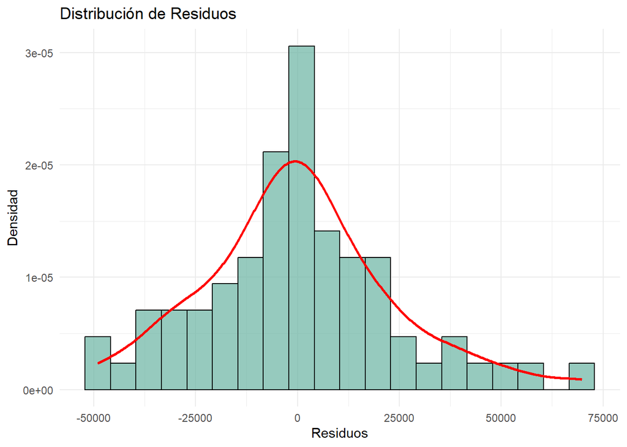

Esta evidencia formal se ve **reforzada visualmente** por el histograma y la curva de densidad superpuesta. Ambos muestran una distribución **simétrica**, con solo una ligera asimetría hacia valores positivos, habitual en series macroeconómicas sujetas a episodios puntuales de mayor volatilidad. Tampoco se observan colas anómalamente pesadas ni acumulaciones atípicas, por lo que la normalidad aproximada se considera razonablemente cumplida.

[interactive chart not shown]

El análisis de autocorrelación (ACF) muestra que prácticamente todos los coeficientes se mantienen dentro del intervalo de confianza, lo que indica que los residuos no presentan **correlación significativa** con sus valores pasados. Solo aparece algún pico puntual de pequeña magnitud, insuficiente para cuestionar la independencia general del ruido. Esto sugiere que el modelo ha capturado correctamente la estructura temporal relevante de la serie.

Prueba de Ljung-Box

|  | Estadístico | Grados.de.libertad | p.valor |
| --- | --- | --- | --- |
| X-squared | 10.687 | 10 | 0.3824 |

Finalmente, la prueba de Ljung-Box confirma esta conclusión. El **p-valor (0.3824)** es claramente superior al umbral habitual de significación, por lo que no se rechaza la hipótesis nula de independencia de los residuos. En consecuencia, no se detecta **autocorrelación** remanente y se valida que el modelo está bien especificado.

En conjunto, el comportamiento de los residuos, tanto en su distribución, como en su magnitud, independencia y resumen estadístico, indica que el modelo ARIMA ajustado para España es **sólido** y **adecuado** para los objetivos de predicción establecidos.

- **ALEMANIA**

[interactive chart not shown]

En el caso de **Alemania**, los resultados del diagnóstico residual muestran que el modelo ARIMA ajustado captura de forma adecuada la dinámica de la serie temporal. En el gráfico de residuos en el tiempo se observa una evolución **irregular** sin patrones claros ni tendencias persistentes. Aunque aparecen algunos picos marcados, especialmente a comienzos de los años 2000 y durante la crisis financiera, estos responden a shocks transitorios y no reflejan un fallo sistemático en la especificación del modelo. Además, podemos observar como al final de la serie no se aprecia ninguna fluctuación, debido a que se tuvo que completar la serie por la falta de trimestres. En términos generales, los residuos se comportan como **ruido blanco**, lo cual es consistente con un buen ajuste.

Resumen Estadístico de los Residuos – Alemania

| Var1 | Var2 | Freq |
| --- | --- | --- |
| A | Min. | -227306.4615 |
| A | 1st Qu. | -15277.5170 |
| A | Median | 5.2487 |
| A | Mean | 116.9454 |
| A | 3rd Qu. | 27748.1125 |
| A | Max. | 115522.5541 |

El resumen estadístico aporta información complementaria sobre la distribución de los residuos. La **mediana** se sitúa muy próxima a cero (5.25), lo que indica ausencia de sesgo direccional relevante. La **media** (116.94) también es prácticamente nula en proporción a la escala de la serie, lo que confirma que el modelo no tiende a sobreestimar o infraestimar de forma sistemática. Los **cuartiles** muestran que el 50% central de los residuos se encuentra entre aproximadamente –15.278 y 27.748, reflejando una dispersión moderada y coherente con la variabilidad observada en los datos originales. Los **valores extremo** mínimo (–227.306) y máximo (115.522) indican la presencia de algunos episodios **atípicos**, habituales en series económicas sujetas a shocks de elevada magnitud, pero no sugieren problemas estructurales en el ajuste.

Test de Normalidad Shapiro-Wilk de los Residuos

|  | Estadístico | p.valor |
| --- | --- | --- |
| W | 0.9091 | 0.0001 |

Para evaluar la normalidad de los residuos se aplicó el **test de Shapiro–Wilk**, que arrojó un estadístico **W = 0.9091** y un **p-valor = 0.0001**. Dado que este valor es claramente inferior al umbral habitual de 0.05, **se rechaza la hipótesis nula de normalidad**. Esto indica que los residuos no siguen una distribución normal y presentan desviaciones apreciables respecto a la forma teórica esperada.

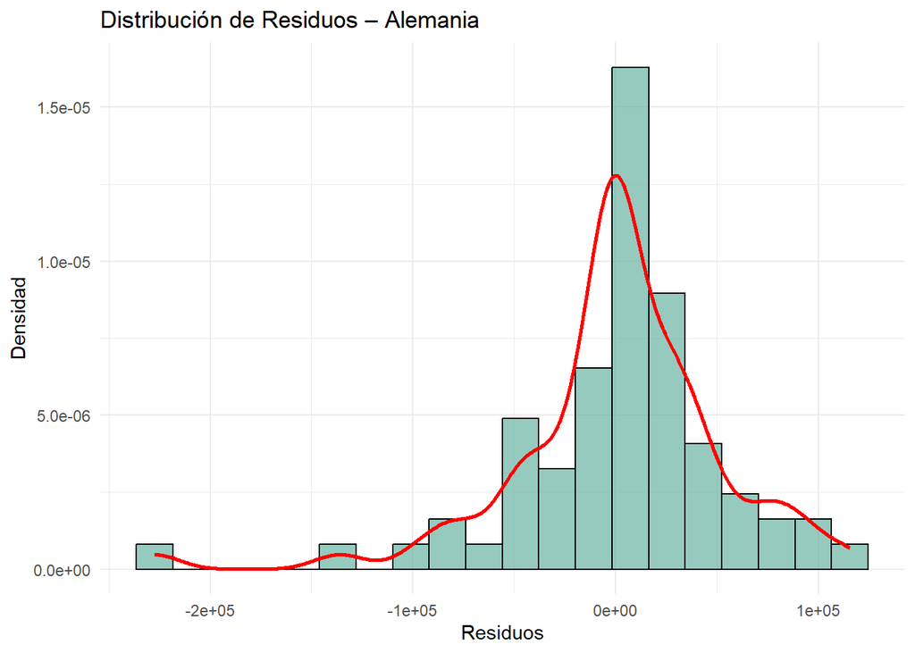

En cuanto al análisis visual, el histograma y la curva de densidad permiten identificar las características que explican este resultado estadístico. Aunque la distribución muestra cierta simetría general, se observan **acumulaciones más pronunciadas alrededor de valores positivos** y una forma menos regular que en una distribución normal ideal. La densidad suavizada revela pequeñas **deformaciones** que sugieren **asimetría** y **colas más pesadas**, lo que es coherente con el rechazo de la normalidad por parte del test formal. Estas desviaciones, aunque no extremas, justifican la conclusión de que la normalidad no se cumple adecuadamente en este caso.

[interactive chart not shown]

El análisis de la función de autocorrelación (ACF) indica que prácticamente todos los coeficientes de autocorrelación se mantienen dentro del intervalo de confianza, lo cual sugiere ausencia de **correlación serial** significativa entre los residuos. Aunque aparece algún pico puntual, su magnitud no es suficiente como para comprometer la independencia general del ruido residual. Esto es indicativo de que el modelo ha recogido adecuadamente la **estructura temporal** de la serie alemana.

Prueba de Ljung-Box – Alemania

|  | Estadístico | Grados.de.libertad | p.valor |
| --- | --- | --- | --- |
| X-squared | 10.419 | 10 | 0.4046 |

- **ITALIA**

[interactive chart not shown]

En el caso de **Italia**, el análisis de los residuos confirma que el modelo ARIMA seleccionado ofrece un **ajuste adecuado** para la serie temporal. El gráfico de residuos en el tiempo muestra oscilaciones irregulares sin tendencias persistentes ni patrones claramente identificables. Aunque aparecen cambios bruscos en algunos periodos, especialmente alrededor de 2009 y en la etapa posterior a 2015, estos corresponden a episodios puntuales de mayor volatilidad económica y no constituyen un problema sistemático en la especificación del modelo. En términos generales, la serie residual se comporta de manera compatible con **ruido blanco**.

Resumen Estadístico de los Residuos – Italia

| Var1 | Var2 | Freq |
| --- | --- | --- |
| A | Min. | -65528.8321 |
| A | 1st Qu. | -9964.2538 |
| A | Median | -405.8099 |
| A | Mean | 3028.0021 |
| A | 3rd Qu. | 20424.4302 |
| A | Max. | 73040.6140 |

El resumen estadístico permite profundizar en la distribución y magnitud de los residuos. La **mediana** se sitúa cerca de cero (-405.80), mientras que la **media** (3028.00) muestra una ligera desviación positiva, coherente con la forma del histograma, donde se aprecia una mayor concentración de valores positivos. Los **cuartiles** indican que el 50% central de los residuos se encuentra entre aproximadamente –9.964 y 20.424, lo cual sugiere una dispersión moderada. Los **valores extremos** (–65.528 y 73.040) evidencian la presencia de algunos episodios atípicos, propios de series económicas expuestas a shocks intensos, pero no suponen un problema de ajuste estructural.

Test de Normalidad Shapiro-Wilk de los Residuos

|  | Estadístico | p.valor |
| --- | --- | --- |
| W | 0.9848 | 0.5775 |

Se evaluó la normalidad de los residuos mediante el **test de Shapiro–Wilk**, obteniéndose un estadístico **W = 0.9848** y un **p-valor = 0.5775**. Como el p-valor supera ampliamente el umbral de 0.05, **no se rechaza la hipótesis nula**, indicando que los residuos se ajustan de manera adecuada a una distribución normal.

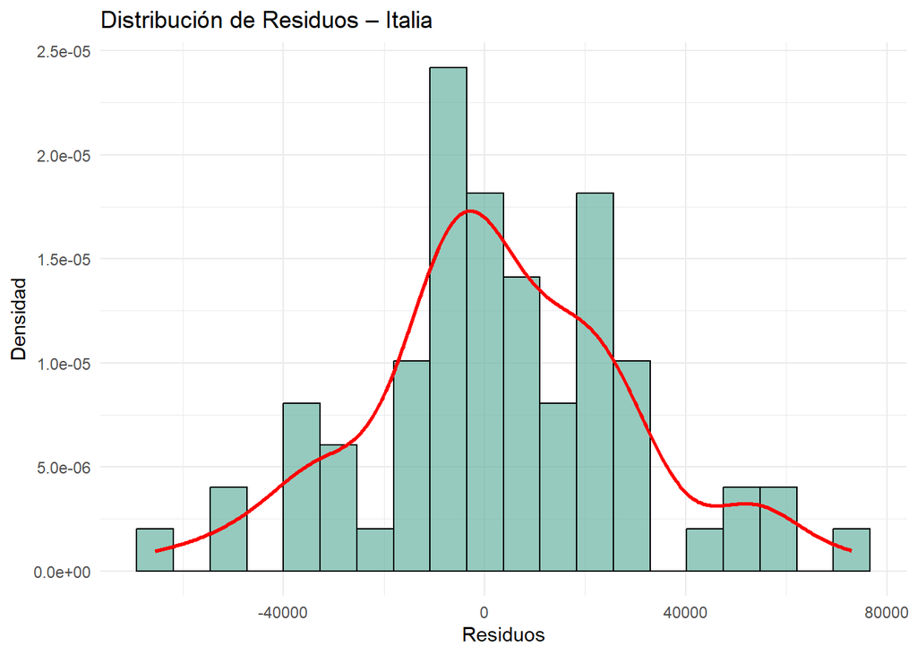

Desde un punto de vista gráfico, el histograma y la curva de densidad muestran que la mayoría de los residuos se concentran alrededor de la media, con una **ligera inclinación hacia valores positivos**, lo que refleja una leve asimetría típica en series económicas. No se identifican colas particularmente largas ni acumulaciones atípicas, por lo que la **distribución de los residuos puede considerarse razonablemente normal**, respaldando la validez del modelo para análisis posteriores.

[interactive chart not shown]

La función de autocorrelación (ACF) de los residuos muestra que la mayoría de los coeficientes se mantienen dentro de los intervalos de confianza, lo cual sugiere **independencia** entre los residuos y **ausencia de correlación** serial relevante. Algunos picos aislados aparecen, pero su magnitud no es suficiente para comprometer la validez del modelo. Este comportamiento indica que el modelo ARIMA ha capturado correctamente la estructura temporal fundamental de la serie italiana.

Prueba de Ljung-Box – Italia

|  | Estadístico | Grados.de.libertad | p.valor |
| --- | --- | --- | --- |
| X-squared | 9.88 | 10 | 0.4511 |

Finalmente, la prueba de **Ljung-Box** refuerza esta conclusión. El **p-valor** obtenido **(0.4511)** es claramente superior a los niveles habituales de significación, por lo que no se rechaza la hipótesis nula de independencia de los residuos. Esto implica que no existe autocorrelación remanente y que el modelo está **bien especificado** desde el punto de vista estadístico.

En conjunto, la magnitud, distribución e independencia de los residuos confirman que el modelo ajustado para Italia es **sólido** y **adecuado** para los objetivos de análisis y predicción establecidos.

#### 3.7.2.1 Comparativa final

En esta sección se analizan los resultados de los modelos **ARIMA** aplicados a España, Alemania e Italia, considerando su ajuste a los datos históricos y su capacidad predictiva. La comparación evidencia **diferencias** significativas entre los países.

Comparativa de los Mejores Modelos ARIMA por País

| Pais | Modelo | AIC | MAPE | RMSE |
| --- | --- | --- | --- | --- |
| España | Auto.ARIMA Básico | 1521.03 | 7.13 | 71858 |
| Alemania | RW con Drift | 1657.88 | 19.57 | 623259 |
| Italia | Auto.ARIMA Básico | 1547.34 | 175.56 | 99877 |

- **Precisión de los modelos (MAPE):** **España** presenta la mayor precisión, con un MAPE de **7.13** en el modelo **Auto.ARIMA básico**, lo que indica que las predicciones se ajustan muy bien a los valores reales. **Alemania**, con un modelo **RW con drift**, alcanza un MAPE de **19.57**, lo que refleja un ajuste aceptable, aunque con mayor **error relativo** que España. **Italia**, en cambio, muestra un MAPE de **175.56**, lo que indica que el modelo falla casi por completo en la predicción y que la serie temporal es **altamente difícil** de modelar con ARIMA básico.
- **Error absoluto de predicción (RMSE):** El **RMSE** también refleja esta disparidad: **Alemania** tiene el mayor error absoluto **(623,259)**, **España** el menor **(71,858)** e **Italia** presenta un RMSE de **99,877**, intermedio, lo que indica que aunque los errores absolutos no son enormes comparados con Alemania, la gran desviación relativa de Italia se refleja en el MAPE **extremadamente alto**.
- **Elección de modelo final:** La selección de modelo priorizó la **capacidad de predicción**. **España** se beneficia del ajuste automático de Auto.ARIMA, **Alemania** encuentra en RW con drift un modelo más adecuado a la volatilidad de sus datos, mientras que **Italia** evidencia que el enfoque ARIMA básico no es suficiente para pronosticar de manera confiable, sugiriendo la necesidad de explorar modelos más complejos o transformaciones de la serie.

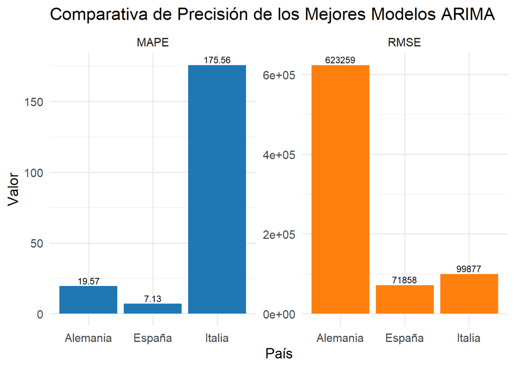

- **Conclusión comparativa:** La comparativa evidencia que la capacidad predictiva depende fuertemente de la **estabilidad** de la serie temporal. **España** se destaca por su ajuste excelente, **Alemania** muestra un desempeño aceptable pero con mayor error, e **Italia** representa un desafío predictivo significativo, lo que pone de relieve las limitaciones del modelo ARIMA frente a series con alta volatilidad o comportamientos atípicos.

### 3.7.3 Predicción contrafactual

Una vez ya hemos podido ver una **predicción general** según el mejor modelo y los valores dados. El siguiente paso en mi investigación sobre el **impacto de la Crisis del 2008** consistirá en calcular la predicción de la posición de inversión internacional que habría tenido cada país en ausencia de la crisis. Esta **predicción contrafactual** permite estimar cómo habría evolucionado la **IIP neta** si los flujos financieros hubieran continuado siguiendo la **tendencia histórica pre-crisis**. A partir de esta predicción, se podrá cuantificar el **efecto del shock económico** mediante el cálculo de la **desviación promedio**, la **caída máxima** y la **comparación de impactos** entre países. La diferencia entre la serie real y la predicción indica el grado de **ajuste forzoso** provocado por la crisis, mostrando si la caída de la IIP neta se frenó por la reducción de los **pasivos**, de los **activos** o de ambos. Este análisis permitirá evaluar la **asimetría** en la reacción de cada economía europea ante el **shock financiero global**.

- **ESPAÑA**

El primer pais que voy a analizar en profundidad es España. Comenzaré agrupando en una tabla los **valores reales** de la serie y los **valores predichos** en ausencia de la crisis, calculando su diferencia y ademas indicando la diferencia porcentual.

Impacto de la Crisis 2008-2011 sobre la IIP Neta de España

| Fecha | Real | Predicho_sin_crisis | Diferencia | Diferencia_pct |
| --- | --- | --- | --- | --- |
| 2008-02-29 | -946957 | -958689.4 | 11732.43 | -1.22% |
| 2008-05-31 | -957365 | -1001096.9 | 43731.86 | -4.37% |
| 2008-08-31 | -953755 | -1043504.3 | 89749.30 | -8.6% |
| 2008-11-30 | -946469 | -1085911.7 | 139442.73 | -12.84% |
| 2009-02-28 | -965499 | -1128319.2 | 162820.16 | -14.43% |
| 2009-05-31 | -1007404 | -1170726.6 | 163322.59 | -13.95% |
| 2009-08-31 | -1036438 | -1213134.0 | 176696.02 | -14.57% |
| 2009-11-30 | -1043004 | -1255541.5 | 212537.46 | -16.93% |
| 2010-02-28 | -1027207 | -1297948.9 | 270741.89 | -20.86% |
| 2010-05-31 | -971265 | -1340356.3 | 369091.32 | -27.54% |
| 2010-08-31 | -1020417 | -1382763.8 | 362346.75 | -26.2% |
| 2010-11-30 | -975107 | -1425171.2 | 450064.18 | -31.58% |
| 2011-02-28 | -1014177 | -1467578.6 | 453401.61 | -30.89% |
| 2011-05-31 | -1016767 | -1509986.1 | 493219.05 | -32.66% |
| 2011-08-31 | -1013313 | -1552393.5 | 539080.48 | -34.73% |
| 2011-11-30 | -997082 | -1594800.9 | 597718.91 | -37.48% |

[interactive chart not shown]

Para poder entender qué **componentes** de la **IIP neta** explican el **frenazo** que podemos apreciar en el anterior gráfico, es necesario descomponer la serie en **Activos y Pasivos**. Esto permitirá identificar si la **estabilización** se debe principalmente a una caída de los activos españoles en el exterior, a una reducción de los pasivos externos en España, o a la combinación de ambos efectos.

[interactive chart not shown]

Durante la **crisis 2008–2011**, los **activos españoles en el exterior** se mantuvieron alrededor de 1.5 millones EUR, mientras que los **pasivos externos** permanecieron en torno a 2.5 millones EUR. Esto indica que la **estabilización** observada en la IIP neta agregada se debió principalmente a un **ajuste de los pasivos**, y no a un aumento de los activos.

Para comprender con mayor detalle qué **sectores económicos** contribuyeron a este comportamiento, el siguiente gráfico descompone la IIP neta por sector. Este análisis permite identificar si la **moderación de la caída** se concentró en **sectores específicos** o si fue un **fenómeno generalizado** que afectó de manera similar a todos los agentes económicos.

[interactive chart not shown]

La **descomposición sectorial** permite observar cómo cada agente económico contribuyó al **comportamiento agregado** de la IIP neta durante la crisis. Aunque algunos sectores como “otras instituciones” mostraron incrementos marginales, los **sectores más relevantes**, como las **administraciones públicas** y los **bancos centrales**, continuaron descendiendo, lo que explica que la IIP neta agregada no se recuperara realmente.

Ahora que comprendemos el **frenazo en la caída** de la **Posición de Inversión Internacional Neta** durante la crisis, podemos analizar cómo se habría comportado cada componente según la **predicción contrafactual**. Este ejercicio permitirá identificar la **tendencia** que habrían seguido los flujos en ausencia de la crisis y cuantificar la **contribución específica** de cada componente al movimiento observado de la IIP neta.

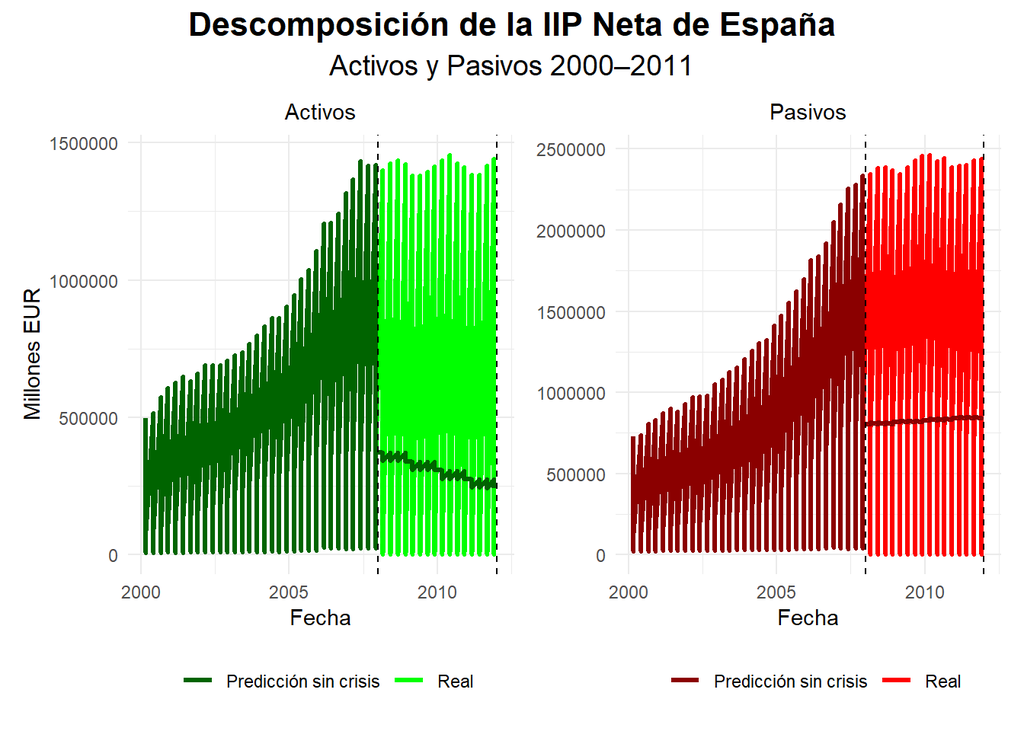

Ahora que hemos comparado las **trayectorias reales** con las **predicciones contrafactuales**, se aprecia que el **frenazo** en la caída de la IIP neta durante la crisis no respondió a una **mejora estructural**, sino a un **cambio de tendencia** respecto al escenario sin crisis. Según la predicción, los **activos** habrían continuado disminuyendo y los **pasivos** habrían seguido aumentando, profundizando el deterioro de la posición exterior. Sin embargo, la **crisis** alteró este patrón: los activos y pasivos se estabilizaron, generando un **ajuste abrupto** que contuvo temporalmente la caída de la **IIP neta**. En este sentido, la estabilización observada no fue una recuperación de la capacidad inversora del país.

Tras analizar el impacto de la crisis 2008–2011 sobre la **IIP neta** de España, el siguiente paso es estudiar su evolución durante la fase post-crisis, hasta finales de 2019, para evitar el impacto del COVID-19. Esto permite evaluar si la recuperación fue **generalizada** o **asimétrica**, identificar qué sectores o componentes contribuyeron a la mejora y comprender cómo se estabilizó la **posición exterior neta** tras el shock financiero global.

[interactive chart not shown]

Tras la fase de crisis, la IIP neta de España muestra una recuperación parcial durante el periodo 2012–2019, pasando de aproximadamente -975000 a -900000 millones EUR. Este comportamiento indica que, aunque la economía continuó ajustándose tras el shock financiero, se produjo un **cambio de tendencia positivo**, con los flujos netos estabilizándose y generando una mejora gradual de la posición exterior neta. La serie general refleja que la economía española no volvió inmediatamente a los niveles pre-crisis, pero logró **contener parcialmente el deterioro**, marcando el inicio de una fase de recuperación moderada. Para comprender mejor los factores detrás de esta recuperación, se descompone el periodo por **sectores**, lo que permitirá analizar el comportamiento individual de cada agente económico.

[interactive chart not shown]

Al descomponer la **IIP neta** por sectores, se observa un comportamiento heterogéneo que explica la dinámica agregada:

- **Administraciones Públicas** continuaron cayendo, ejerciendo presión negativa sobre la recuperación de la IIP neta.
- **Sociedades No Financieras** se mantuvieron relativamente estables, con contribuciones marginalmente negativas, sin frenar ni impulsar significativamente la mejora.
- **Bancos Centrales y Otras Instituciones Financieras** experimentaron un crecimiento moderado, contribuyendo positivamente a la recuperación y ayudando a contener la caída total.
- **Total Economía**, a pesar de la recuperación parcial, todavía presenta una ligera caída neta, reflejando que la mejora se concentró principalmente en sectores financieros y no fue homogénea.

Este análisis sectorial permite entender que la recuperación post-crisis fue asimétrica, como algunos sectores absorbieron el impacto de la crisis y otros continuaron ajustándose, configurando el patrón observado en la **IIP neta agregada**.

Como hemos observado en la evolución de la **Posición de Inversión Internacional (IIP)** de España, resulta fundamental analizar su trayectoria a largo plazo para comprender cómo la crisis de 2008 alteró la composición y la sostenibilidad de los balances externos. La siguiente tabla resume la evolución anual de los activos, pasivos y la posición neta entre 2000 y 2024, incorporando además la variación relativa respecto al nivel previo a la crisis y la ratio entre activos y pasivos, un indicador clave del grado de cobertura exterior de la economía.

Resumen de la IIP neta y sus componentes en España (millones de euros)

| Año | Activos | Neto | Pasivos | Var. Neto vs 2007 (%) | Activos/Pasivos (%) |
| --- | --- | --- | --- | --- | --- |
| 2000 | 4,809,271 | -2,086,779 | 6,029,681 | -71.2 | 79.8 |
| 2001 | 6,019,794 | -2,465,117 | 7,260,153 | -66.0 | 82.9 |
| 2002 | 6,824,413 | -3,004,366 | 8,226,496 | -58.6 | 83.0 |
| 2003 | 7,984,368 | -3,709,789 | 9,505,964 | -48.8 | 84.0 |
| 2004 | 9,199,770 | -4,340,357 | 10,991,884 | -40.1 | 83.7 |
| 2005 | 11,059,030 | -5,161,791 | 13,129,791 | -28.8 | 84.2 |
| 2006 | 13,188,415 | -5,881,312 | 15,692,290 | -18.9 | 84.0 |
| 2007 | 14,451,578 | -7,248,215 | 18,246,639 | 0.0 | 79.2 |
| 2008 | 17,672,493 | -8,159,290 | 20,326,469 | 12.6 | 86.9 |
| 2009 | 17,627,714 | -8,578,093 | 20,803,436 | 18.3 | 84.7 |
| 2010 | 17,169,366 | -8,589,533 | 21,062,557 | 18.5 | 81.5 |
| 2011 | 16,133,073 | -8,442,055 | 20,704,648 | 16.5 | 77.9 |
| 2012 | 16,270,383 | -7,301,654 | 20,048,926 | 0.7 | 81.2 |
| 2013 | 27,638,850 | -9,870,939 | 26,431,566 | 36.2 | 104.6 |
| 2014 | 28,551,955 | -11,131,055 | 28,197,946 | 53.6 | 101.3 |
| 2015 | 31,599,837 | -10,949,254 | 29,793,370 | 51.1 | 106.1 |
| 2016 | 33,638,092 | -10,714,708 | 30,703,663 | 47.8 | 109.6 |
| 2017 | 36,818,540 | -10,878,917 | 32,906,905 | 50.1 | 111.9 |
| 2018 | 39,285,269 | -11,559,788 | 34,643,496 | 59.5 | 113.4 |
| 2019 | 40,195,610 | -11,468,188 | 36,396,731 | 58.2 | 110.4 |
| 2020 | 36,378,987 | -11,792,856 | 32,895,622 | 62.7 | 110.6 |
| 2021 | 39,546,663 | -12,085,507 | 34,932,026 | 66.7 | 113.2 |
| 2022 | 42,398,954 | -10,642,802 | 35,163,619 | 46.8 | 120.6 |
| 2023 | 44,462,185 | -10,818,401 | 36,491,575 | 49.3 | 121.8 |
| 2024 | 48,448,177 | -11,202,126 | 38,968,921 | 54.6 | 124.3 |

La evolución de la **Posición de Inversión Internacional Neta (IIP)** de España entre 2000 y 2024 se puede dividir en tres fases claramente diferenciadas: expansión previa a la crisis, deterioro durante la crisis financiera global y recuperación posterior con crecimiento más acelerado de los activos que de los pasivos.

Este comportamiento sirve como punto de referencia para analizar si la **recuperación española** fue un fenómeno singular o si responde a una dinámica común dentro del contexto europeo. A continuación, se abordará la comparación entre países, con el objetivo de identificar la existencia de patrones **asimétricos** en el impacto y la recuperación de la IIP tras la crisis global de 2008.

- **ALEMANIA**

Una vez ya hemos analizado y visto en detalle los datos sobre España, procedere de la misma manera con Alemania. De esta forma podremos ver de una manera clara las diferencias en el comportamiento y reaccion de los paises al shock económico.

Para analizar la evolución de la **IIP neta** y comprender la **subida sostenida** que observamos en los gráficos anteriores, es útil comparar la serie **real** con la **contrafactual**. Esta comparación permite evaluar cómo se habría comportado la IIP neta en ausencia de la crisis y, por tanto, identificar el impacto específico de los eventos económicos adversos.

Impacto de la Crisis 2008-2011 sobre la IIP Neta de Alemania

| Fecha | Real | Predicho_sin_crisis | Diferencia | Diferencia_pct |
| --- | --- | --- | --- | --- |
| 2008-02-29 | 333574 | 305013.1 | 28560.895 | 9.36% |
| 2008-05-31 | 414685 | 318564.2 | 96120.789 | 30.17% |
| 2008-08-31 | 464864 | 332115.3 | 132748.684 | 39.97% |
| 2008-11-30 | 426817 | 345666.4 | 81150.579 | 23.48% |
| 2009-02-28 | 409853 | 359217.5 | 50635.474 | 14.1% |
| 2009-05-31 | 479232 | 372768.6 | 106463.368 | 28.56% |
| 2009-08-31 | 448030 | 386319.7 | 61710.263 | 15.97% |
| 2009-11-30 | 529992 | 399870.8 | 130121.158 | 32.54% |
| 2010-02-28 | 529486 | 413422.0 | 116064.053 | 28.07% |
| 2010-05-31 | 565582 | 426973.0 | 138608.947 | 32.46% |
| 2010-08-31 | 509051 | 440524.2 | 68526.842 | 15.56% |
| 2010-11-30 | 539260 | 454075.3 | 85184.737 | 18.76% |
| 2011-02-28 | 565861 | 467626.4 | 98234.632 | 21.01% |
| 2011-05-31 | 541809 | 481177.5 | 60631.526 | 12.6% |
| 2011-08-31 | 482163 | 494728.6 | -12565.579 | -2.54% |
| 2011-11-30 | 501174 | 508279.7 | -7105.684 | -1.4% |

[interactive chart not shown]

Al comparar ambas series, podemos ver que ambas muestran una **tendencia ascendente**, lo que sugiere que factores estructurales y de largo plazo están impulsando el crecimiento.

Para profundizar en los **componentes** que explican esta subida, es necesario descomponer la IIP neta en **Activos** y **Pasivos**. Esto permitirá identificar si la subida se debe principalmente a una **crecida de los activos alemanes en el exterior**, a una **reducción de los pasivos externos en Alemania**, o a la **combinación de ambos efectos**.

[interactive chart not shown]

Para comprender con mayor detalle qué sectores económicos impulsaron este crecimiento, el siguiente gráfico descompone la **IIP neta** por **sector**. Este análisis permite identificar si la **subida** se concentró en sectores específicos o si fue un fenómeno generalizado que afectó de manera similar a todos los agentes económicos.

[interactive chart not shown]

La **descomposición sectorial** permite observar cómo cada **agente económico** contribuyó al comportamiento agregado de la **IIP neta** durante la crisis. En el caso de Alemania, la economía total experimentó un **incremento notable**, mientras que sectores como otras instituciones mostraron descensos marginales y el resto de los sectores se mantuvieron relativamente estables. Este patrón explica que la IIP neta agregada experimentara una **subida sostenida** durante el periodo.

Ahora que comprendemos la subida de la **Posición de Inversión Internacional Neta** durante la crisis, podemos analizar cómo se habría comportado cada componente según la **predicción contrafactual**. Este ejercicio permitirá identificar la tendencia que habrían seguido los flujos en ausencia de la crisis y cuantificar la contribución específica de cada componente al movimiento observado de la IIP neta.

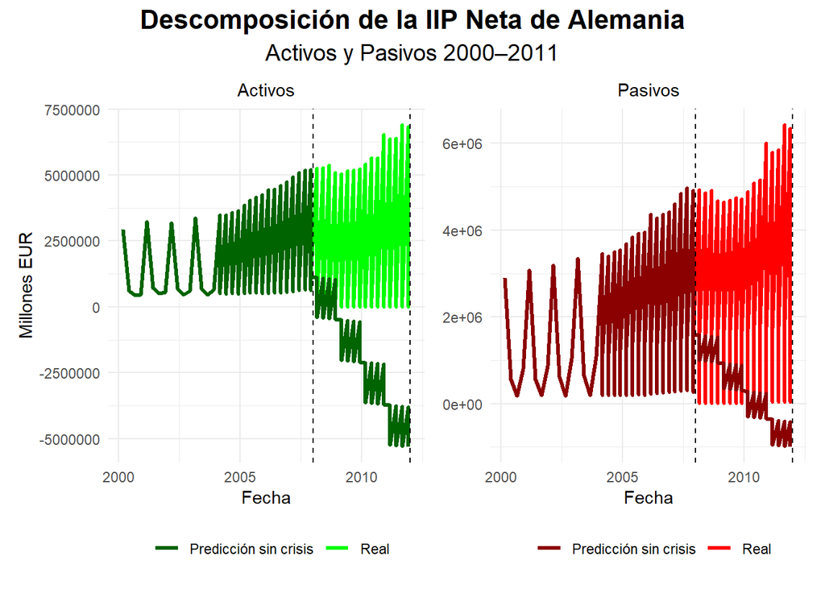

Tras analizar el impacto de la crisis 2008–2011 sobre la IIP neta de Alemania, el siguiente paso es estudiar su evolución durante la fase **post-crisis** hasta finales de 2019, para evitar el impacto del COVID-19. Esto permitirá evaluar si la recuperación fue **generalizada o asimétrica**, identificar qué **sectores** o **componentes** contribuyeron a la mejora y comprender cómo se consolidó la **posición exterior neta** tras el shock financiero global.

[interactive chart not shown]

Tras la fase de crisis, la **IIP neta** de Alemania muestra un **crecimiento constante** durante el periodo 2012–2019, pasando de aproximadamente **500.000 millones EUR** hasta cerca de **2.000.000 millones EUR**. Este comportamiento indica que la economía alemana no solo se ajustó tras el shock financiero, sino que consolidó una **tendencia positiva**, con los **flujos netos** aumentando de forma sostenida y generando una mejora continua de la **posición exterior neta**. La serie general refleja que Alemania logró fortalecer su posición exterior agregada de manera progresiva, marcando una fase de **recuperación sólida y estable**.

Para comprender mejor los factores detrás de este crecimiento, se descompone el periodo por **sectores**, lo que permitirá analizar el comportamiento individual de cada **agente económico** y la contribución de cada componente al incremento de la **IIP neta**.

[interactive chart not shown]

Al descomponer la **IIP neta** de Alemania por **sectores**, se observa un comportamiento heterogéneo que explica la dinámica agregada:

- **Total Economía** continúa mostrando un **crecimiento sostenido**, reflejando que la recuperación post-crisis fue generalizada a nivel agregado.
- **Bancos Centrales** y **Otras Instituciones Financieras** permanecen **estables**, sin contribuir significativamente ni al crecimiento ni a la caída, manteniendo su participación constante en la posición exterior neta.
- **Administraciones Públicas** muestran un **amago de subida**, pero todavía se mantienen en terreno **negativo**, ejerciendo una presión limitada sobre la IIP neta agregada.

Este análisis sectorial permite entender que, aunque la **recuperación post-crisis** en Alemania fue más **generalizada** que en otros países, algunos sectores continuaron ajustándose de manera desigual, configurando el patrón observado en la **IIP neta agregada**.

Como hemos observado en la evolución de la **Posición de Inversión Internacional (IIP)** de Alemania, resulta fundamental analizar su trayectoria a largo plazo para comprender cómo la crisis de 2008 alteró la composición y sostenibilidad de los balances externos. La siguiente tabla resume la evolución anual de los **activos**, **pasivos** y la **posición neta** entre 2000 y 2024, incorporando además la variación relativa respecto al nivel previo a la crisis y la **ratio entre activos y pasivos**, un indicador clave del grado de cobertura exterior de la economía.

Resumen de la IIP neta y sus componentes en Alemania (millones de euros)

| Año | Activos | Neto | Pasivos | Var. Neto vs 2007 (%) | Activos/Pasivos (%) |
| --- | --- | --- | --- | --- | --- |
| 2000 | 4,712,744 | -9,760 | 4,436,876 | -100.6 | 106.2 |
| 2001 | 5,358,784 | 297,995 | 4,714,382 | -80.5 | 113.7 |
| 2002 | 5,304,687 | -67,089 | 5,039,832 | -104.4 | 105.3 |
| 2003 | 5,541,415 | -95,354 | 5,292,511 | -106.2 | 104.7 |
| 2004 | 23,457,365 | -88,314 | 22,075,999 | -105.8 | 106.3 |
| 2005 | 26,582,386 | 553,278 | 24,494,629 | -63.9 | 108.5 |
| 2006 | 29,672,705 | 976,890 | 27,032,518 | -36.2 | 109.8 |
| 2007 | 33,420,593 | 1,531,621 | 29,991,523 | 0.0 | 111.4 |
| 2008 | 60,226,387 | 1,465,250 | 41,989,664 | -4.3 | 143.4 |
| 2009 | 59,478,337 | 967,340 | 42,032,001 | -36.8 | 141.5 |
| 2010 | 65,112,576 | 1,777,104 | 45,832,081 | 16.0 | 142.1 |
| 2011 | 69,923,937 | 453,701 | 51,508,085 | -70.4 | 135.8 |
| 2012 | 89,689,851 | 1,078,186 | 57,256,861 | -29.6 | 156.6 |
| 2013 | 133,158,181 | 6,228,760 | 60,196,293 | 306.7 | 221.2 |
| 2014 | 139,679,464 | 6,873,960 | 61,612,811 | 348.8 | 226.7 |
| 2015 | 149,804,128 | 8,558,146 | 64,506,206 | 458.8 | 232.2 |
| 2016 | 154,841,688 | 10,053,211 | 65,325,265 | 556.4 | 237.0 |
| 2017 | 159,830,295 | 13,375,288 | 64,982,373 | 773.3 | 246.0 |
| 2018 | 164,175,984 | 15,931,226 | 65,282,368 | 940.2 | 251.5 |
| 2019 | 178,211,168 | 18,242,614 | 70,034,843 | 1091.1 | 254.5 |
| 2020 | 160,189,688 | 13,909,914 | 66,127,665 | 808.2 | 242.2 |
| 2021 | 169,711,821 | 16,185,277 | 69,759,573 | 956.7 | 243.3 |
| 2022 | 176,245,165 | 18,754,864 | 72,809,407 | 1124.5 | 242.1 |
| 2023 | 170,409,433 | 18,648,652 | 74,663,014 | 1117.6 | 228.2 |
| 2024 | 181,006,784 | 20,545,009 | 78,301,615 | 1241.4 | 231.2 |

- **ITALIA**

Ahora es el turno de analizar el último país de los 3, Italia. De esta manera, una vez analizado en profundidad, podremos realizar las comparaciones entre ellos y ademas, ver y comprender mejor porque esta crisis se caracteriza por ser asimétrica.

Impacto de la Crisis 2008-2011 sobre la IIP Neta de Italia

| Fecha | Real | Predicho_sin_crisis | Diferencia | Diferencia_pct |
| --- | --- | --- | --- | --- |
| 2008-02-29 | -366427 | -352891.6 | -13535.36 | 3.84% |
| 2008-05-31 | -363598 | -349228.1 | -14369.86 | 4.11% |
| 2008-08-31 | -326140 | -367664.6 | 41524.59 | -11.29% |
| 2008-11-30 | -354405 | -405363.5 | 50958.48 | -12.57% |
| 2009-02-28 | -353612 | -419823.9 | 66211.89 | -15.77% |
| 2009-05-31 | -363099 | -438671.2 | 75572.17 | -17.23% |
| 2009-08-31 | -363947 | -440524.7 | 76577.66 | -17.38% |
| 2009-11-30 | -351592 | -423429.2 | 71837.20 | -16.97% |
| 2010-02-28 | -342112 | -428192.1 | 86080.10 | -20.1% |
| 2010-05-31 | -315270 | -428771.7 | 113501.74 | -26.47% |
| 2010-08-31 | -361466 | -445096.8 | 83630.76 | -18.79% |
| 2010-11-30 | -324347 | -478915.3 | 154568.33 | -32.27% |
| 2011-02-28 | -356981 | -492542.4 | 135561.40 | -27.52% |
| 2011-05-31 | -355459 | -510033.0 | 154574.02 | -30.31% |
| 2011-08-31 | -314038 | -512976.0 | 198937.97 | -38.78% |
| 2011-11-30 | -300093 | -499755.2 | 199662.23 | -39.95% |

[interactive chart not shown]

Para analizar la evolución de la **IIP neta** y comprender el **frenazo en la caída** que observamos en el gráfico anterior, es útil comparar la serie **real** con la **contrafactual**. Esta comparación permite evaluar cómo se habría comportado la IIP neta en ausencia de la crisis y, por tanto, identificar el impacto específico de los eventos económicos adversos.

Al comparar ambas series, se observa que la serie **real** se **modera durante la crisis**, mientras que la serie **contrafactual** sigue descendiendo, aunque de manera más **suave que en el caso de España**. Esto sugiere que, aunque Italia sufrió un impacto negativo, la contención de la caída fue más gradual y menos pronunciada.

Para profundizar en los componentes que explican este comportamiento, es necesario descomponer la **IIP neta** en **Activos** y **Pasivos**, como en los otros casos de España y Alemania. Esto permitirá identificar si la **moderación de la caída** se debe principalmente a una **crecida de los activos italianos en el exterior**, a una **reducción de los pasivos externos en Italia**, o a la **combinación de ambos efectos**, ofreciendo así una visión detallada de los factores que sustentan la trayectoria de la **IIP neta**.

[interactive chart not shown]

Durante la crisis 2008–2011, los activos italianos en el exterior se mantuvieron alrededor de **2.000.000 millones EUR**, mientras que los pasivos externos permanecieron en torno a **2.500.000 millones EUR**, experimentando un **crecimiento muy limitado**. Esto indica que la **moderación de la caída** observada en la IIP neta agregada se debió principalmente a un **ajuste de los pasivos**, más que a un aumento significativo de los activos.

Para comprender con mayor detalle qué **sectores económicos** contribuyeron a este comportamiento, el siguiente gráfico descompone la IIP neta por **sector**. Este análisis permite identificar si la **contención de la caída** se concentró en sectores específicos o si fue un fenómeno más **generalizado**, afectando de manera similar a todos los **agentes económicos**.

[interactive chart not shown]

La descomposición **sectorial** permite observar cómo cada **agente económico** contribuyó al comportamiento agregado de la **IIP neta** durante la crisis. En Italia, las **Administraciones Públicas** experimentaron una caída en el medio de la crisis, pero lograron recuperarse hacia el final del periodo, mientras que los **Bancos** mostraron un aumento leve. Por su parte, **Otras Instituciones** registraron un descenso moderado y el **Total Economía** presentó únicamente una caída mínima.

Ahora que comprendemos el frenazo en la caída de la IIP neta durante la crisis, podemos analizar cómo se habría comportado cada componente según la **predicción contrafactual**. Este ejercicio permitirá identificar la **tendencia** que habrían seguido los flujos en ausencia de la crisis y cuantificar la **contribución específica** de cada componente al movimiento observado de la IIP neta en Italia.

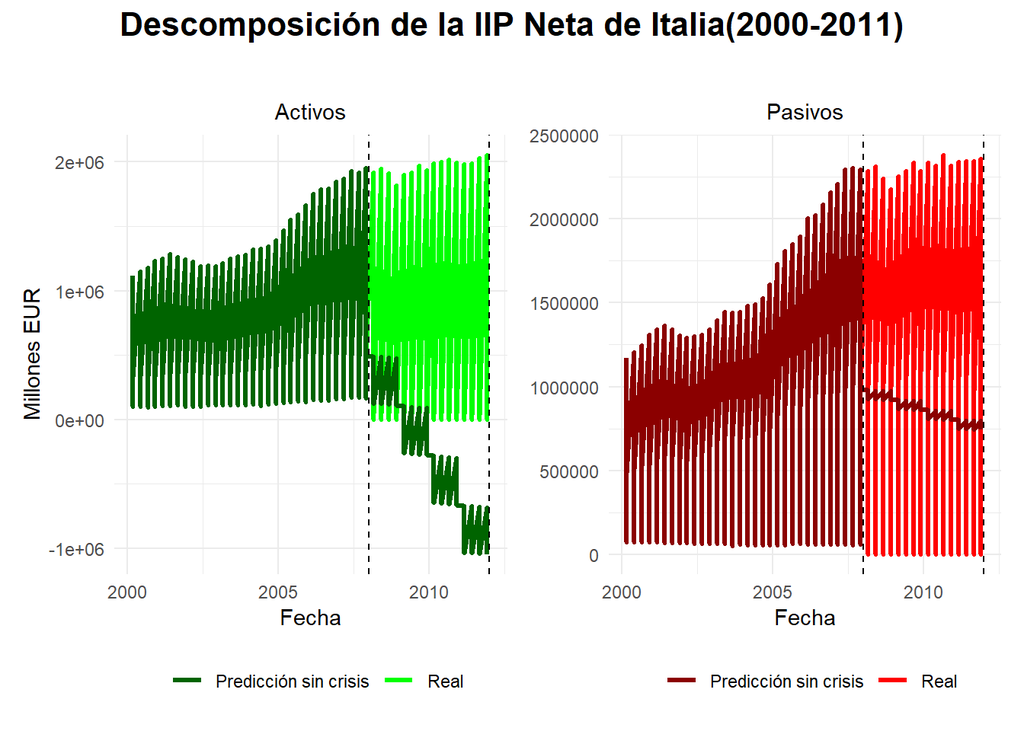

Tras analizar el impacto de la crisis 2008–2011 sobre la IIP neta de Italia, el siguiente paso es estudiar su evolución durante la fase **post-crisis** hasta finales de 2019, para evitar el impacto del COVID-19. Esto permitirá evaluar si la recuperación fue **generalizada o asimétrica**, identificar qué **sectores o componentes** contribuyeron a la mejora y comprender cómo se estabilizó la **posición exterior neta** tras el shock financiero global.

[interactive chart not shown]

Tras la fase de crisis, la IIP neta de Italia muestra un comportamiento mixto durante el periodo 2012–2019. Entre 2012 y 2014 se observa una **bajada temporal**, seguida de un **crecimiento sostenido** hasta 2019, con una pequeña caída en 2015. Este patrón indica que, aunque la economía italiana sufrió ajustes adicionales tras el shock financiero, se produjo un **cambio de tendencia positivo**, con los flujos netos estabilizándose y generando una mejora gradual de la posición exterior neta.

La serie general refleja que, a diferencia de España, donde la recuperación fue más lenta y parcial, Italia logró mantener una **recuperación progresiva**, consolidando su IIP neta durante la mayor parte del periodo post-crisis. Para comprender mejor los factores detrás de esta trayectoria, se descompone el periodo por **sectores**, lo que permitirá analizar el comportamiento individual de cada **agente económico** y su contribución al fortalecimiento de la **posición exterior neta**.

[interactive chart not shown]

Al analizar la descomposición sectorial de la IIP neta de Italia se aprecia una dinámica claramente diferenciada entre agentes. El **Total de la Economía** inicia una senda de recuperación a partir de 2015, aunque el saldo agregado permanece en terreno negativo, reflejando un proceso de ajuste aún incompleto. Dentro de esta evolución, las **Administraciones Públicas** continúan registrando descensos persistentes, convirtiéndose en el principal factor que limita la mejora de la posición exterior del país.

Por su parte, las **Sociedades No Financieras** muestran un avance progresivo y se aproximan a abandonar los valores negativos, aunque sin llegar a cruzar el umbral positivo durante el periodo analizado. En contraste, el **Banco Central** mantiene de forma estable una posición claramente positiva, actuando como uno de los pilares que contribuyen a sostener el saldo agregado.

Finalmente, el comportamiento de **Otras Instituciones Financieras** resulta especialmente relevante: este sector experimenta una caída continuada hasta 2014, llegando a situarse en valores negativos, pero a partir de ese punto inicia una fase de crecimiento sostenido que le permite recuperar terreno y consolidarse en positivo de manera estable.

En conjunto, estos patrones confirman que la recuperación de la IIP italiana tras la crisis fue **heterogénea y gradual**, concentrándose principalmente en los sectores financieros, mientras que el sector público continuó lastrando el avance del conjunto de la economía.

Ahora, la tabla siguiente recoge la evolución anual de los activos, los pasivos y la posición neta de Italia entre 2000 y 2024, e incluye también la variación porcentual respecto al nivel previo a la crisis y la relación entre activos y pasivos, un indicador fundamental para medir la capacidad de la economía para respaldar sus obligaciones externas.

Resumen de la IIP neta y sus componentes en Italia (millones de euros)

| Año | Activos | Neto | Pasivos | Var. Neto vs 2007 (%) | Activos/Pasivos (%) |
| --- | --- | --- | --- | --- | --- |
| 2000 | 7,739,883 | -2,202,894 | 9,942,759 | -57.7 | 77.8 |
| 2001 | 8,301,375 | -2,498,746 | 10,800,100 | -52.1 | 76.9 |
| 2002 | 8,003,967 | -2,672,847 | 10,676,815 | -48.7 | 75.0 |
| 2003 | 8,345,511 | -3,555,150 | 11,900,661 | -31.8 | 70.1 |
| 2004 | 8,967,837 | -3,566,677 | 12,534,515 | -31.6 | 71.5 |
| 2005 | 10,429,369 | -4,572,669 | 15,002,036 | -12.3 | 69.5 |
| 2006 | 11,887,969 | -4,948,278 | 16,836,247 | -5.1 | 70.6 |
| 2007 | 12,851,822 | -5,213,818 | 18,065,642 | 0.0 | 71.1 |
| 2008 | 20,813,206 | -4,591,754 | 19,684,785 | -11.9 | 105.7 |
| 2009 | 21,251,400 | -5,358,306 | 20,542,853 | 2.8 | 103.4 |
| 2010 | 22,087,619 | -5,449,354 | 21,190,628 | 4.5 | 104.2 |
| 2011 | 21,872,570 | -4,826,287 | 20,797,063 | -7.4 | 105.2 |
| 2012 | 22,262,652 | -4,121,342 | 21,022,358 | -21.0 | 105.9 |
| 2013 | 40,515,159 | -4,846,331 | 25,948,675 | -7.0 | 156.1 |
| 2014 | 41,255,344 | -6,071,225 | 27,597,346 | 16.4 | 149.5 |
| 2015 | 45,234,361 | -6,479,289 | 29,705,268 | 24.3 | 152.3 |
| 2016 | 46,589,641 | -5,535,034 | 29,237,449 | 6.2 | 159.3 |
| 2017 | 48,597,934 | -4,120,595 | 28,780,227 | -21.0 | 168.9 |
| 2018 | 50,254,892 | -3,405,694 | 28,967,747 | -34.7 | 173.5 |
| 2019 | 53,121,959 | -3,171,790 | 30,169,156 | -39.2 | 176.1 |
| 2020 | 48,141,410 | -3,689,959 | 27,951,067 | -29.2 | 172.2 |
| 2021 | 50,717,682 | -4,246,360 | 29,891,161 | -18.6 | 169.7 |
| 2022 | 49,174,357 | -3,233,289 | 30,044,949 | -38.0 | 163.7 |
| 2023 | 51,509,170 | -3,135,524 | 31,148,580 | -39.9 | 165.4 |
| 2024 | 56,696,133 | -3,270,069 | 33,671,694 | -37.3 | 168.4 |

## 3.8 Despliegue

El objetivo del **despliegue es garantizar** que los resultados obtenidos en este proyecto puedan ser utilizados de forma práctica para el seguimiento y análisis de la **Posición de Inversión Internacional Neta (IIP Neta)** de España, Alemania e Italia, así como para la evaluación de escenarios contrafactuales ante posibles shocks financieros futuros.

### 3.8.1 Productos finales y forma de entrega

Los resultados del proyecto se presentan a través de varios productos:

- **Informe final:** incluye análisis comparativo, gráficos de evolución histórica, análisis contrafactual y conclusiones por país.
- **Tablas y series procesadas:** los dataframes con series temporales y predicciones pueden exportarse a formatos estándar (CSV, Excel) para su reutilización.
- **Cuadro de mandos interactivo:** construido con herramientas de visualización dinámicas (Shiny o plotly), permite explorar los datos, visualizar las series temporales y los escenarios contrafactuales de manera interactiva, facilitando la interpretación por usuarios no técnicos.

### 3.8.2 Uso de los modelos

Los modelos **ARIMA** y los análisis **contrafactuales** se pueden aplicar para:

- **Predicciones futuras** de la IIP neta por país, permitiendo estimar tendencias y riesgos potenciales.
- **Simulación de escenarios:** evaluar cómo posibles shocks financieros o crisis afectarían la posición exterior de cada país, comparando resultados con la trayectoria histórica.
- **Soporte a la toma de decisiones:** identificar vulnerabilidades estructurales y planificar estrategias de estabilidad económica.

Es importante tener en cuenta que los modelos son **univariantes**, por lo que no incorporan choques externos específicos ni interacciones con variables macroeconómicas externas.

### 3.8.3 Mantenimiento y actualización

- Las series temporales y los modelos pueden actualizarse trimestralmente con nuevos datos, recalibrando los modelos para obtener predicciones actualizadas.
- El cuadro de mandos puede integrarse con fuentes de datos en tiempo real o actualizaciones periódicas, ofreciendo a los usuarios una herramienta dinámica para el seguimiento continuo de la IIP.

### 3.8.4 Integración en entornos institucionales

- Exportación de resultados y predicciones a herramientas de reporting como **Excel**, **Power BI** o **Tableau**.
- Posibilidad de generar **alertas automáticas** si la IIP se desvía significativamente de la trayectoria prevista.
- Uso del dashboard como herramienta de comunicación para presentar escenarios a responsables de política económica, facilitando decisiones basadas en evidencia cuantitativa.

En conjunto, estas herramientas y procedimientos aseguran que los resultados del proyecto no solo tengan valor académico, sino también **aplicación práctica** y utilidad para la toma de decisiones económicas y financieras.

# 4 Conclusiones y trabajo futuro

## 4.1 Conclusiones

El presente trabajo abordó el análisis de la **Posición de Inversión Internacional Neta (IIP Neta)** en España, Alemania e Italia, demostrando una marcada **asimetría estructural** en la respuesta de estas economías a la **Crisis Financiera Global de 2008**.

La contribución de este análisis radica en la **cuantificación del efecto del shock** (mediante los contrafactuales) y la posterior evaluación de la estabilidad de la recuperación (mediante la predictibilidad de los modelos), revelando que la divergencia entre los países no solo reside en la magnitud de su saldo exterior, sino en la **calidad estructural** y **fiabilidad** de sus trayectorias post-crisis.

### 4.1.1 La Evolución Histórica Comparada (Series Temporales)

[interactive chart not shown]

El gráfico comparativo de las tres series de **IIP Neta** establece el punto de partida y la divergencia estructural entre los países:

- **Alemania (Línea Ascendente)**: Muestra una tendencia de crecimiento casi ininterrumpida a lo largo de las dos décadas, consolidando su posición como principal acreedor de la Zona Euro.
- **España e Italia (Líneas Negativas)**: Muestran una marcada caída previa a 2008, seguida de una estabilización durante la crisis. Ambas iniciaron una recuperación lenta después de 2012, manteniéndose en saldo deudor.

Este punto confirma la **asimetría preexistente**, pero el análisis más profundo es el que cuantifica cómo la crisis alteró esas tendencias y cómo de estables son las nuevas trayectorias.

### 4.1.2 La Cuantificación del Impacto (Análisis Contrafactual)

A partir de la interpretación de los gráficos contrafactuales presentados anteriormente, donde se comparó la Serie Real con el escenario Predicho en ausencia de crisis, es posible aislar el efecto neto del shock de 2008. Dichos resultados permiten identificar tres patrones de respuesta claramente diferenciados entre los países analizados:

- **Alemania: El Refuerzo Estructural**

- **España e Italia: La Interrupción de la Tendencia de Deterioro**

En contraste, para España e Italia los gráficos mostraban cómo la serie real se estabilizaba durante la crisis, rompiendo la trayectoria descendente marcada por el escenario sin crisis. Esta desviación indica que el shock forzó un ajuste abrupto en los flujos financieros, frenando el deterioro que, de haberse mantenido la tendencia previa, habría profundizado la vulnerabilidad externa. En ambos casos, la crisis actuó como un mecanismo que impidió alcanzar los niveles de desequilibrio proyectados en el contrafactual.

### 4.1.3 La Divergencia en la Capacidad Predictiva

Mientras que los contrafactuales nos muestran el impacto del shock, la evaluación de la **capacidad predictiva** de los modelos ARIMA en el período 2016-2024 nos dice cómo de fiable es la recuperación. La siguiente tabla, junto con el **Margen de Error Absoluto de la Predicción (MAPE)** son la prueba cuantitativa definitiva de la asimetría en la estabilidad:

Resumen de modelos seleccionados por país

| Pais | Modelo | AIC | MAPE |
| --- | --- | --- | --- |
| España | Auto.ARIMA básico(0,2,1) | 1521.03 | 7.13 |
| Alemania | RW con drift(0,0,1) | 1657.88 | 19.57 |
| Italia | Auto.ARIMA(1,2,2)(0,0,1)[4] | 1547.34 | 175.56 |

El MAPE del **7.13%** para **España** establece el patrón de **máxima estabilidad** entre los deudores: el ajuste post-crisis ha generado una trayectoria de recuperación altamente predecible.

En contraste, el MAPE extremo de **175.56%** para **Italia** indica un fallo predictivo, evidenciado en las grandes oscilaciones de su serie real post-crisis . Esto demuestra que, aunque Italia logró frenar el deterioro, su recuperación carece de la **estabilidad estructural** necesaria, dejándola vulnerable a shocks futuros.

### 4.1.4 Conclusión final global

En resumen, la evidencia confirma que la **asimetría entre países** va más allá de los saldos deudores:

- **Alemania**: Consolidó su posición de fuerza y riqueza.
- **España**: Logró una recuperación estable y predecible, demostrando que sus ajustes estructurales han funcionado en términos de estabilidad financiera.
- **Italia**: Su recuperación es inestable e impredecible, manteniéndola como la economía más vulnerable del grupo.

La principal aportación es que la **estabilidad de las series**, medida por el MAPE, es la métrica clave para distinguir la calidad de la recuperación entre los países deudores.

## 4.2 Trabajo futuro

El presente análisis ofrece una visión completa de la **IIP neta** de España, Alemania e Italia y su comportamiento frente a la crisis de 2008. No obstante, existen múltiples líneas de trabajo futuro que podrían ampliar y profundizar los hallazgos:

- **Actualización y extensión de series temporales**: Incorporar datos más recientes permitirá mantener los modelos predictivos actualizados y evaluar la evolución de la IIP frente a eventos recientes, como la pandemia de COVID-19 o tensiones financieras globales.
- **Integración de variables complementarias**: Incluir información macroeconómica adicional, como población, actividad industrial, comercio exterior o políticas fiscales, permitiría realizar análisis más detallados sobre los determinantes de la IIP y mejorar la comprensión de los flujos financieros por país.
- **Ampliación de la muestra de países**: Extender el estudio a otros países europeos o globales posibilitaría comparar la resiliencia de distintas economías ante crisis financieras y detectar patrones comunes o divergencias estructurales.
- **Desarrollo de modelos predictivos avanzados**: Incorporar modelos multivariantes, técnicas de aprendizaje automático o modelos estructurales podría mejorar la capacidad predictiva frente a series altamente volátiles y permitir análisis de escenarios más complejos.
- **Análisis sectorial y contrafactual más detallado**: Refinar la descomposición por sectores y contrapartes, así como incluir subsectores económicos, facilitaría identificar con mayor precisión qué componentes sostienen la estabilidad o generan vulnerabilidad en cada país.

Estas líneas de trabajo futuro permitirían no solo **mejorar la robustez del análisis**, sino también proporcionar **herramientas más precisas para la toma de decisiones económicas y financieras** a nivel nacional e internacional.

## Anexo. Seguimiento temporal actividades del proyecto

TOTAL HORAS TRABAJADAS EN EL PROYECTO : 69.69

[interactive chart not shown]

**DESGLOSE DETALLADO DE LAS SESIONES DE TRABAJO**

|  | START | END | MINUTES | ACTIVITY | FINAL COMMENT |
| --- | --- | --- | --- | --- | --- |
| 1 | 2025-09-26T16:32:17Z | 2025-09-26T19:18:29Z | 166.2 | Compresión del negocio | Busqueda del tema |
| 2 | 2025-09-26T20:04:37Z | 2025-09-26T21:54:43Z | 110.1 | Comprensión de los datos | Modelo validación del tema |
| 3 | 2025-09-26T23:23:24Z | 2025-09-27T01:30:48Z | 127.4 | Comprensión de los datos | Modelo validación del tema |
| 4 | 2025-09-27T11:14:03Z | 2025-09-27T12:08:45Z | 54.7 | Comprensión de los datos | Modelo validación del tema |
| 5 | 2025-10-05T12:57:57Z | 2025-10-05T15:55:32Z | 177.6 | Comprensión de los datos | Memoria |
| 6 | 2025-10-05T16:56:37Z | 2025-10-05T19:29:05Z | 152.5 | Comprensión de los datos | Memoria |
| 7 | 2025-10-05T22:31:21Z | 2025-10-05T23:11:03Z | 39.7 | Comprensión de los datos | Memoria |
| 8 | 2025-10-06T23:17:12Z | 2025-10-07T00:11:14Z | 54 | Comprensión de los datos | memoria |
| 9 | 2025-10-09T22:42:38Z | 2025-10-09T23:54:30Z | 71.9 | Preparación de los datos | preparacion datos |
| 10 | 2025-10-10T16:32:52Z | 2025-10-10T18:24:34Z | 111.7 | Preparación de los datos | filtrado y graficas |

[output cut: 31 more lines]